# Team 1 Final Project Report

Team 1 (Names: Adam Kritz, Osemekhian Ehilen, Suhas Buravalla, Huang He)

2021-12-14

# Final Project

## Background

### Motivation

Our team decided to return to the diamonds dataset for the final project. With our knowledge from the midterm, we are now looking to start predicting different characteristics of diamonds. We are still interested in diamond price and cut, similar to the midterm, however, this time we are going to use modelling to make our own predictions about price and cut. Our research will continue to enable people to better understand diamonds and make educated decisions when buying or cutting diamonds.

### Disclaimer

Anything in our final report marked as a refresher is either repeated from the midterm, or contains a significant amount of work from the midterm. If you feel knowledgeable about these areas or remember them from the midterm, feel free to skip over them.

### Dataset Refresher

[Here is a link to our dataset](https://www.kaggle.com/shivam2503/diamonds)

Our diamonds dataset comes from Kaggle. Our data was originally sourced from Tiffany & Co.’s snapshot pricelist from 2017. Tiffany and Co. is a large American luxury jewelry corporation, so we felt their data would be applicable to those looking to buy diamonds.

Our dataset has 53,940 observations in it. There are ten unique variables and one ID number for each diamond.

There are three categorical variables that are all ordinal variables:

- Cut - the quality of the cut of the diamond
  - There are five levels of cut, from worst to best: Fair, Good, Very Good, Premium, Ideal
- Color - the quality of the color of the diamond
  - There are seven levels of color, from worst to best: J, I, H, G, F, E, D
- Clarity - the quality of the clarity of the diamond
  - There are eight levels of clarity, from worst to best: I1, SI2, SI1, VS2, VS1, VVS2, VVS1, IF

There are also seven continuous variables that are all ratio variables:

- Price - the price of the diamond in USD
  - Ranges from 326USD - 18,823USD
- Carat - the weight of the diamond
  - Ranges from 0.2 - 5.01
- x - the length of the diamond
  - Ranges from 0 - 10.74
- y - the width of the diamond
  - Ranges from 0 - 58.9
- z - the depth of the diamond
  - Ranges from 0 - 31.8
- Depth - the total depth percentage of the diamond
  - Calculated as: 2 * z / (x + y)
  - Ranges from 43 - 79
- Table - the width of top of diamond relative to widest point
  - Ranges from 43 - 95

Overall, the dataset is relatively clean. However, there are still a few abnormalities in the data.

- There are outliers in a couple of the variables
- There are a few diamonds that have zero values in x, y, or z. This is clearly a mistake, as all diamonds are three dimensional objects.

These issues are addressed in future sections when they present themselves.

### Prior Work on the Diamonds Dataset Refresher

The diamonds dataset is an extremely popular dataset, so there has been plenty of work done on it. Much of this work is done through machine learning or more advanced statistical techniques that are hard for the average person to understand. Our group specifically wanted to create an easy to understand R Markdown file that has clear results from our modelling so the average diamond buyer can understand it.

### SMART Question Development

For the final project, we wanted to use a wide variety of models to predict both price and cut. We researched multiple different kinds of models, and eventually settled on four models to use. Within each of these models, we had questions we wanted to answer throughout the modeling process.

- Linear Model for price
  - What is the best single variable model?
  - What is the best multi variable model with only numeric variables?
  - What is the best model using numeric and categorical variables
  - Can interaction terms or feature selection help to create a better model?

- Principal Component Regression (PCR) for price
  - What can PCR reveal about the data that linear modelling cannot?
  - How is PCR able to understand the known multicollinearity in the data?
  - What is the best model PCR creates?

PCR is a newer modelling technique we are interested in, and we hope it is able to work in tandem with the linear model to predict price. We also hope it can tackle the multicollinearity better than linear models.

- Random Forest Classification for cut
  - How does a random forest classifier compare to logistic regression when it comes to classifying diamonds based on cut?
  - How can we reduce out of bag error for the random forest model?
  - What is the appropriate number of trees for the model
  - Which features are the most important in a random forest model?

Initially we planned to do a logistic regression model, however it performed quite poorly. Instead, we decided to go with a random forest model, and compare it against logistic regression in the process of our research.

- K-Nearest Neighbor (KNN) Classification for cut
  - What is the optimal K value for a KNN classifier?
  - How does changing K affect accuracy?
  - How does changing K affect other methods of evaluation?

KNN classifier is another new modelling technique that can be used to classify diamonds based on their cut.

For models that predicts price, we will be looking at it from a consumer perspective. However, for models that predict cut, we will be looking from the perspective of the workers when they are cutting diamonds.

These SMART questions will guide us through our research and allow us to create the best models for classifying diamonds.

## Importing the Data

Here we import the data, set the index to ID, and set the ordinal variables to factors with order = T.

```r
diamonds = data.frame(read.csv("diamonds.csv"))
diamonds$color = factor(diamonds$color, order=T, levels = c('J', 'I', 'H', 'G', 'F', 'E', 'D'))
diamonds$clarity = factor(diamonds$clarity, order=T, levels = c('I1', 'SI2', 'SI1', 'VS2', 'VS1', 'VVS2', 'VVS1', 'IF'))
diamonds$cut = factor(diamonds$cut, order=T, levels = c('Fair', 'Good', 'Very Good', 'Premium', 'Ideal'))

rownames(diamonds) = diamonds$X
diamonds = subset(diamonds, select = -X)
```

## Explaratory Data Analysis Refresher

### Full Summary

```r
sum = xkablesummary(diamonds, title = "Summary of Diamonds")
sum
```

Summary of Diamonds

|  | carat | cut | color | clarity | depth | table | price | x | y | z |
| --- | --- | --- | --- | --- | --- | --- | --- | --- | --- | --- |
| Min | Min. :0.20 | Fair : 1610 | J: 2808 | SI1 :13065 | Min. :43.0 | Min. :43.0 | Min. : 326 | Min. : 0.00 | Min. : 0.0 | Min. : 0.0 |
| Q1 | 1st Qu.:0.40 | Good : 4906 | I: 5422 | VS2 :12258 | 1st Qu.:61.0 | 1st Qu.:56.0 | 1st Qu.: 950 | 1st Qu.: 4.71 | 1st Qu.: 4.7 | 1st Qu.: 2.9 |
| Median | Median :0.70 | Very Good:12082 | H: 8304 | SI2 : 9194 | Median :61.8 | Median :57.0 | Median : 2401 | Median : 5.70 | Median : 5.7 | Median : 3.5 |
| Mean | Mean :0.80 | Premium :13791 | G:11292 | VS1 : 8171 | Mean :61.7 | Mean :57.5 | Mean : 3933 | Mean : 5.73 | Mean : 5.7 | Mean : 3.5 |
| Q3 | 3rd Qu.:1.04 | Ideal :21551 | F: 9542 | VVS2 : 5066 | 3rd Qu.:62.5 | 3rd Qu.:59.0 | 3rd Qu.: 5324 | 3rd Qu.: 6.54 | 3rd Qu.: 6.5 | 3rd Qu.: 4.0 |
| Max | Max. :5.01 | NA | E: 9797 | VVS1 : 3655 | Max. :79.0 | Max. :95.0 | Max. :18823 | Max. :10.74 | Max. :58.9 | Max. :31.8 |
| NA | NA | NA | D: 6775 | (Other): 2531 | NA | NA | NA | NA | NA | NA |

Here we can see a full summary of the diamonds dataset. In order to better understand the data, let’s look at each variable individually.

### Categorical Data Exploration

In this section we will look at some plots of categorical data

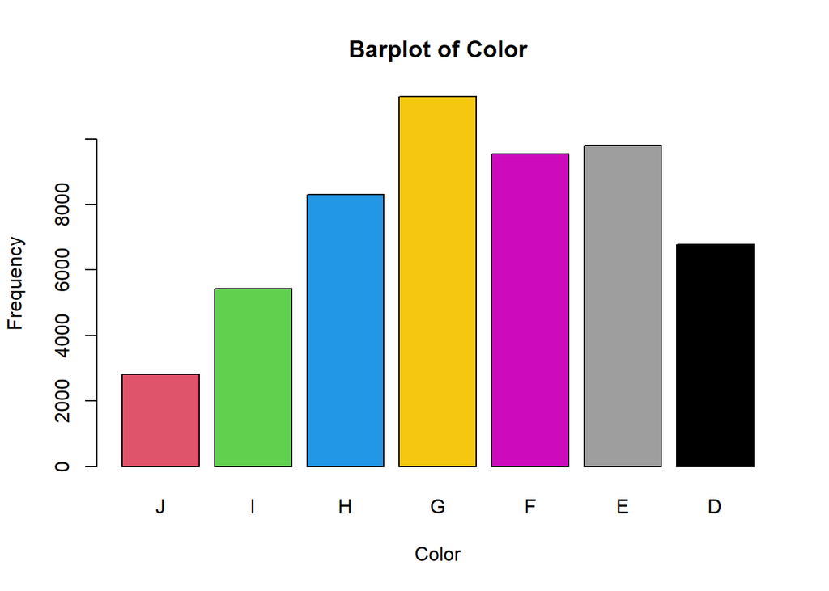

```r
barplot(table(diamonds$color), col = c(2, 3, 4, 7, 6, 8, 9), main = 'Barplot of Color', xlab = "Color", ylab = "Frequency")
```

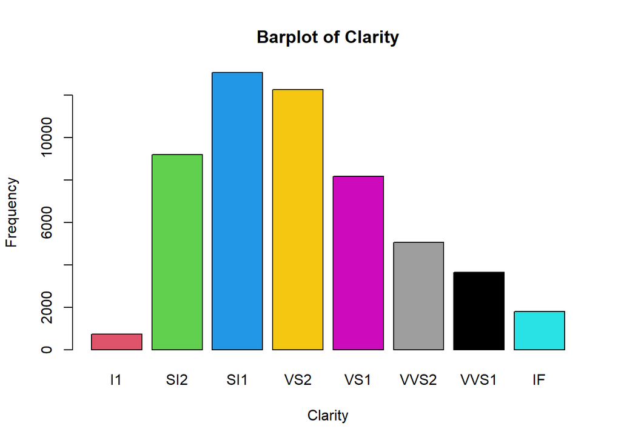

```r
barplot(table(diamonds$clarity), col = c(2, 3, 4, 7, 6, 8, 9, 5), main = 'Barplot of Clarity', xlab = "Clarity", ylab = "Frequency")
```

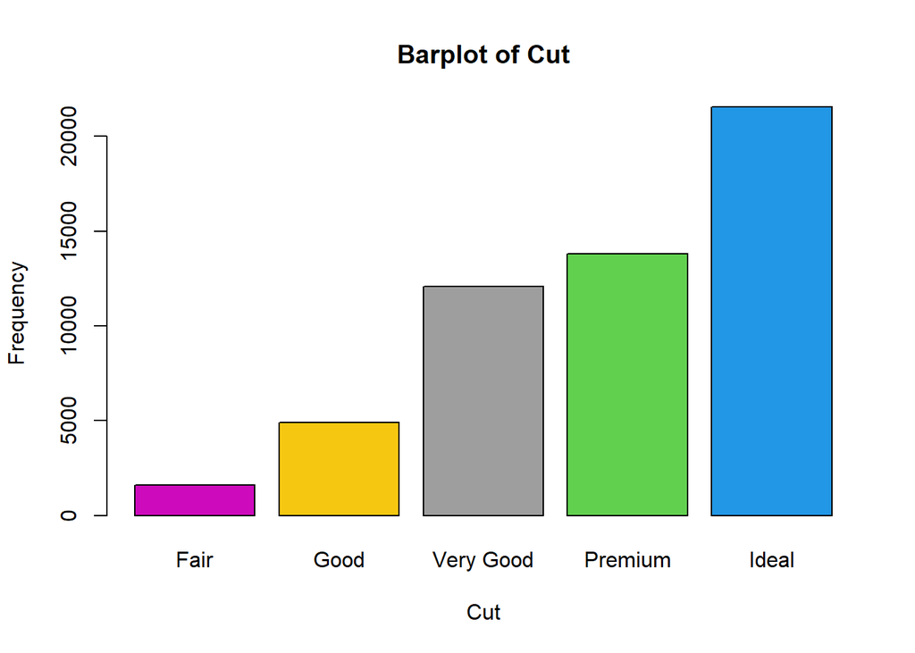

```r
barplot(table(diamonds$cut), col = c(6, 7, 8, 3, 4), main = 'Barplot of Cut', xlab = "Cut", ylab = "Frequency")
```

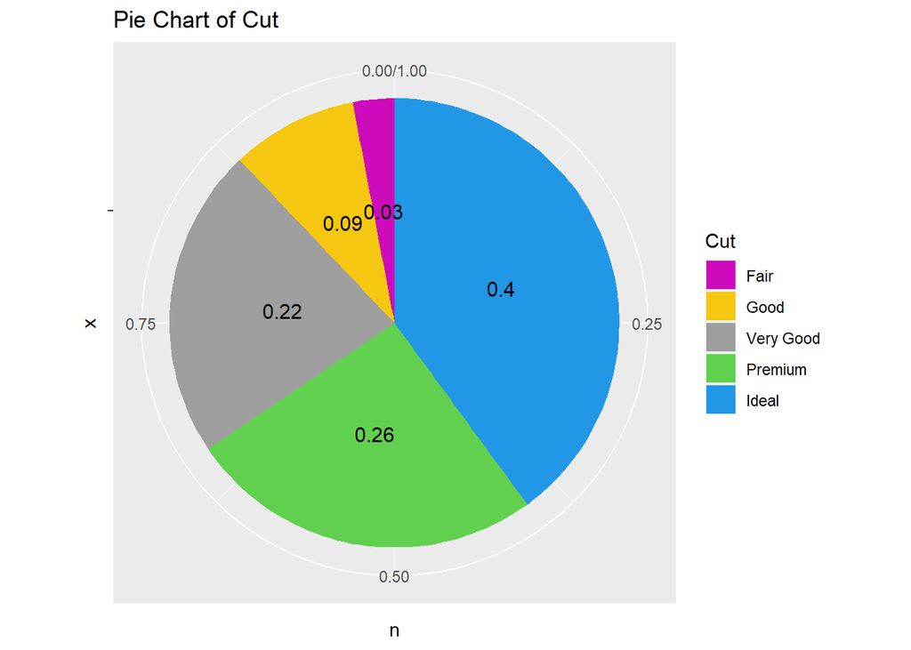

```r
cut_count = dplyr::count(diamonds, cut)
colnames(cut_count)[colnames(cut_count) == 'cut'] <- 'Cut'
cut_count$n = cut_count$n/sum(cut_count$n)

loadPkg("ggplot2")

ggplot(cut_count, aes(x = "", y = n, fill = Cut)) +
  geom_bar(stat="identity", width=1) +
  coord_polar("y", start=0) +
  geom_text(size = 4, aes(label = paste0(round(n, 2), "")), position = position_stack(vjust = 0.5))+
  scale_fill_manual(values = c(6, 7, 8, 3, 4))+
  labs(title='Pie Chart of Cut')
```

Cut has a different spread compared to the other two variables. In this case, the highest quantity of diamonds, 21551, are located at the top at the Ideal level. The least are located in the Fair level, only containing 1610 diamonds. As the level of cut increases, so do the quantity of diamonds in that level.

To better visualize the differences in cut, we also created a pie chart. Ideal diamonds make up 40% of the data. If you were to combine all Fair, Good, and Premium diamonds, there would still be more Ideal diamonds. This vast discrepancy should be noted when looking at the coming research.

### Continious Data Exploration

In this section we will look at all the continuous variables besides price.

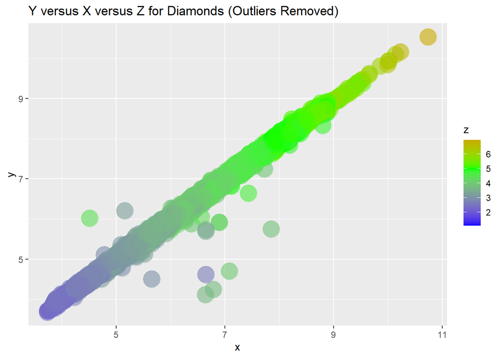

```r
diaNO = subset(diamonds, x > 0 & y > 0 & z > 0 & y <30 & z <30)
ggplot(diaNO, aes(x, y, color=z)) +
  geom_point(size = 8, alpha = 0.6) +
  ggtitle('Y versus X versus Z for Diamonds (Outliers Removed)') +
  scale_color_gradient2(midpoint = 5, low="blue", mid="green", high="red")
```

Here we can see a plot of x, y, and z, or the length, width, and depth of diamonds. A few outliers were removed for this plot, so there are no values at zero or above thirty, in order to improve the readability of the plot. This plot shows a general trend in the data, that x, y, and z all increase and decrease together. In other words, higher x means higher y means higher z.

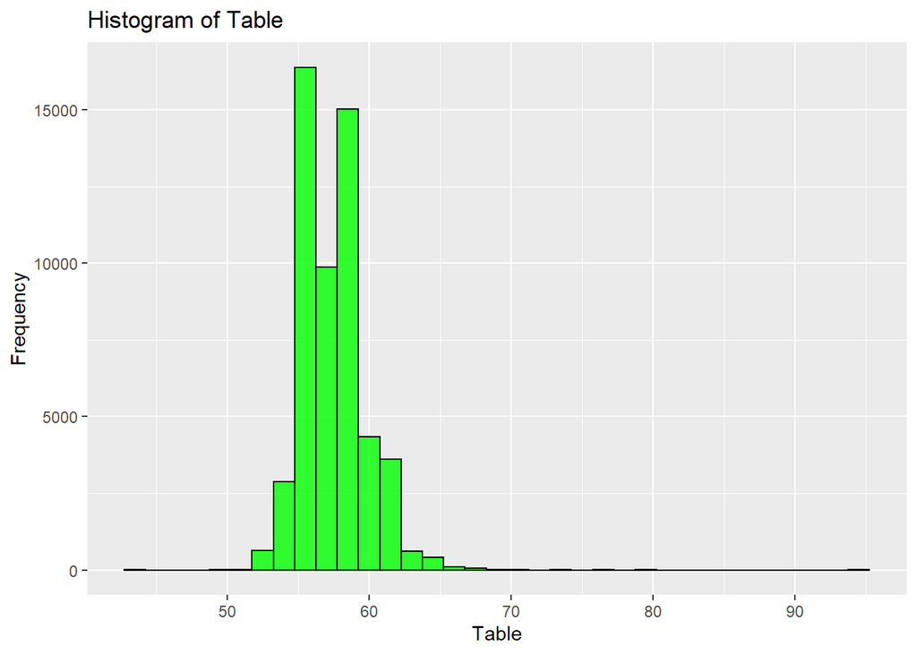

```r
ggplot(diamonds, aes(y=table)) +
  geom_histogram(col="black",
                 fill="green",
                  alpha = .8,
                 binwidth = 1.5) +
  labs(title='Histogram of Table') +
  coord_flip() +
  labs(y="Table", x="Frequency")
```

Table is the first of two extremely centralized variables, as can be seen from the histogram. The quantity of diamonds on the edges is so small, it cannot even be seen. The mean of table is 57.457 and the standard deviation is 2.234, which is reflected in the histogram.

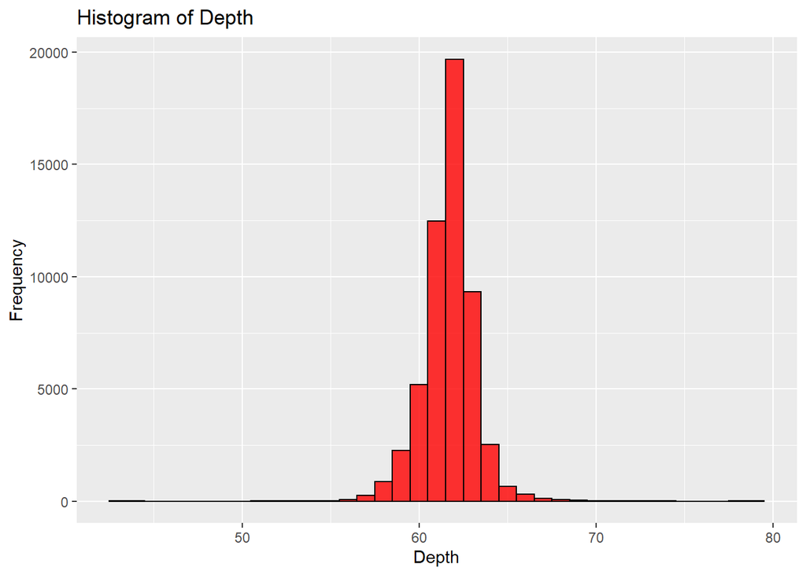

```r
ggplot(diamonds, aes(y=depth)) +
  geom_histogram(col="black",
                 fill="red",
                  alpha = .8,
                 binwidth = 1) +
  coord_flip() +
  labs(title='Histogram of Depth') +
  labs(y="Depth", x="Frequency")
```

Depth is the second of the extremely centralized variables. This is reflected again in the mean, 61.749, and the standard deviation, 1.433. This can also be seen in the histogram, with all of the data extremely centralized around the mean.

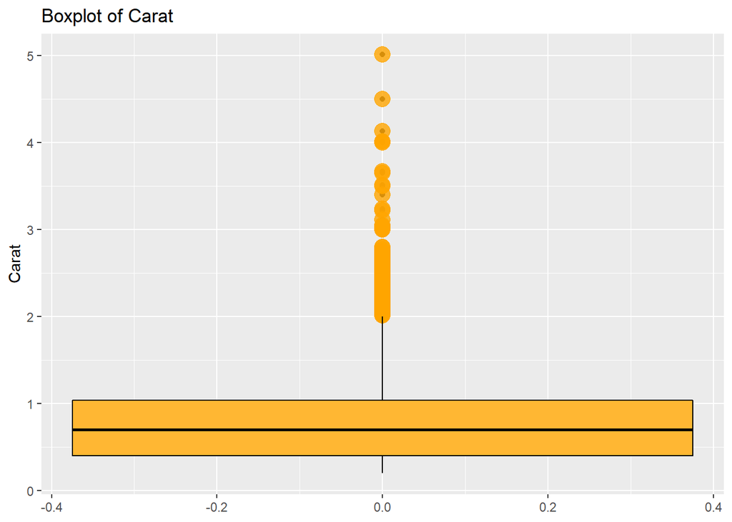

```r
ggplot(diamonds, aes(y=carat)) +
  geom_boxplot() +
  geom_boxplot(colour="black", fill="orange", outlier.colour="orange", outlier.size=5, alpha = 0.8) +
  labs(title = 'Boxplot of Carat')+
  labs(y="Carat")
```

Carat has a much different spread than table and depth, though the values are still grouped together. However, this time they are near the bottom, as every value above 2 is considered an outlier for carat. Overall, the carat distribution is extremely right skewed. The mean of carat is 0.798 and the standard deviation is 0.474.

### Price Exploration

Here are a couple plots on price.

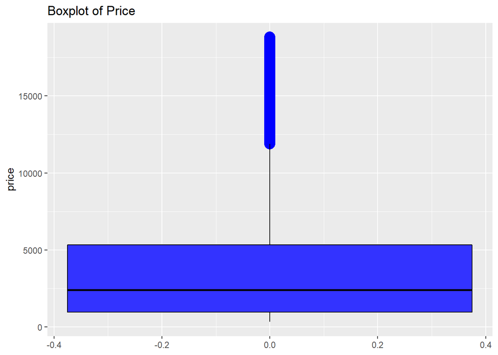

```r
ggplot(diamonds, aes(y=price)) +
  geom_boxplot() +
  geom_boxplot(colour="black", fill="blue", outlier.colour="blue", outlier.size=5, alpha = 0.8) +
  labs(title = 'Boxplot of Price')
```

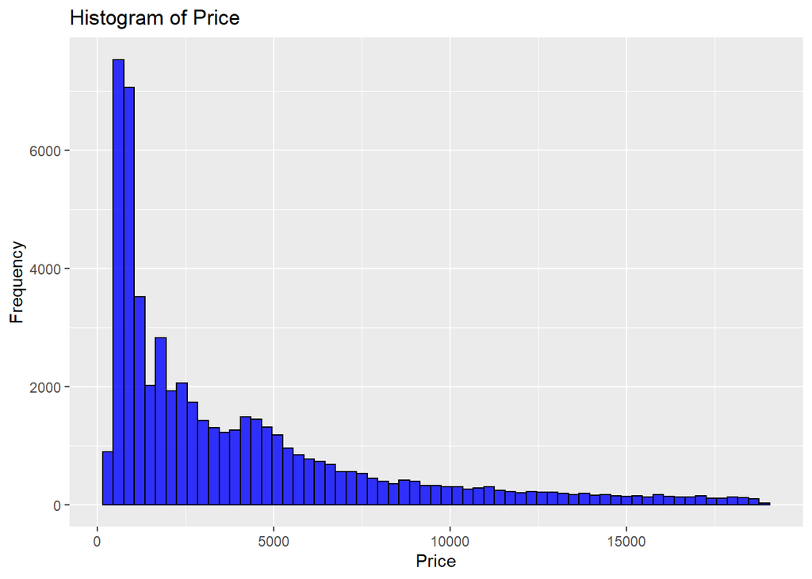

```r
ggplot(diamonds, aes(y=price)) +
  geom_histogram(col="black",
                 fill="blue",
                  alpha = .8,
                 binwidth = 300) +
  coord_flip() +
  labs(title='Histogram of Price') +
  labs(y="Price", x="Frequency")
```

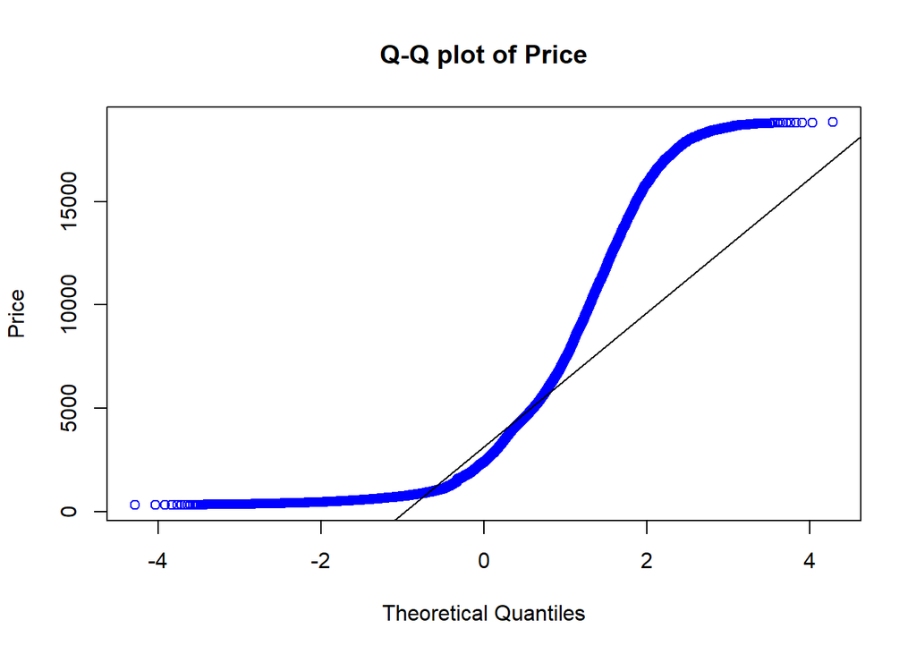

```r
qqnorm(diamonds$price, main="Q-Q plot of Price", col = 'blue', ylab = 'Price')
qqline(diamonds$price)
```

## Data Preprocessing

### Data Cleaning

Unlike the midterm, we need to do a little more cleaning on the data this time in order to do the modelling.

We will be uniformly removing all the outliers in the numerical variables in the dataset to avoid any modelling issues. We removed any outliers in continuous variables with a z-score of less then -3.5 or over 3.5. This removed any clear outliers from the data.

```r
diamondscontT = subset(diamonds, select = c("carat", "depth", "table", "price", "x", "y", "z"))
diamondscat = subset(diamonds, select = c("cut", "color", "clarity"))

z_scores = as.data.frame(sapply(diamondscontT, function(diamondscontT)  (abs(diamondscontT-mean(diamondscontT))/sd(diamondscontT))))
diamondscontT2 = z_scores[!rowSums(z_scores>3.5), ]

RN = row.names(diamondscontT2)
diamonds_No_Out = diamondscontT[rownames(diamondscontT) %in% RN, ]
diamonds_No_OutCat = diamondscat[rownames(diamondscat) %in% RN, ]

diamondsNO = cbind(diamonds_No_Out, diamonds_No_OutCat)

diamondsNo_Out_SC = as.data.frame(scale(diamonds_No_Out, center = TRUE, scale = TRUE))

diamondsNO_SC = cbind(diamondsNo_Out_SC, diamonds_No_OutCat)
```

Upon removing outliers, 1010 outliers were detected and removed.

### Train-Test Split

Since we are creating models, we also need to conduct a train-test split on our data, so we can predict on the testing set. This is not 100% necessary for some of the models, but we decided it would be better to have a uniform train test split for everything. We are going to split the data 0.8 for training and 0.2 for testing. We also set the seed of R to make our results replicable.

We will also be scaling the data for the PCR and KNN models, as they require scaling.

```r
set.seed(1)
samp1 = sample(2, nrow(diamondsNO), replace=TRUE, prob=c(0.8, 0.2))
diamondsNO_train = diamondsNO[samp1==1, ]
diamondsNO_test = diamondsNO[samp1==2, ]
diamondsNO_trainCutLabel = diamondsNO[samp1==1, 8]
diamondsNO_testCutLabel = diamondsNO[samp1==2, 8]
diamondsNO_trainPriceLabel = diamondsNO[samp1==1, 4]
diamondsNO_testPriceLabel = diamondsNO[samp1==2, 4]

diamondsNO_SC_train = diamondsNO_SC[samp1==1, ]
diamondsNO_SC_test = diamondsNO_SC[samp1==2, ]
diamondsNO_SC_trainCutLabel = diamondsNO_SC[samp1 == 1, 8]
diamondsNO_SC_testCutLabel = diamondsNO_SC[samp1 == 2, 8]
diamondsNO_SC_trainPriceLabel = diamondsNO_SC[samp1 == 1, 4]
diamondsNO_SC_testPriceLabel = diamondsNO_SC[samp1 == 2, 4]
```

From here we can move onto answering the SMART questions.

## Linear Regression to predict price

### Single Variable Models

We started by creating one model for each numerical variable. All the models for this section will be created on the train data, and then tested on the test data once we find the best model. We will be using adjusted r-squared as our criteria for the models.

```r
modelcarat <- lm(price ~ carat,data=diamondsNO_train)
modeldepth <- lm(price ~ depth,data=diamondsNO_train)
modeltable <- lm(price ~ table,data=diamondsNO_train)
modelx <- lm(price ~ x,data=diamondsNO_train)
modely <- lm(price ~ y,data=diamondsNO_train)
modelz <- lm(price ~ z,data=diamondsNO_train)
```

Here are the results of the carat model, this turned out to be the best single variable model. It has an adjusted r-squared of 0.855

```r
loadPkg("sjPlot")
loadPkg("sjmisc")
loadPkg("sjlabelled")
tab_model(modelcarat)
```

|  | price |  |  |
| --- | --- | --- | --- |
| Predictors | Estimates | CI | p |
| (Intercept) | -2254.20 | -2281.73 – -2226.67 | **<0.001** |
| carat | 7754.44 | 7723.98 – 7784.90 | **<0.001** |
| Observations | 42373 |  |  |
| R<sup>2</sup> / R<sup>2</sup> adjusted | 0.855 / 0.855 |  |  |

Here are the results from depth and table, neither of which performed very well.

```r
tab_model(modeldepth)
```

|  | price |  |  |
| --- | --- | --- | --- |
| Predictors | Estimates | CI | p |
| (Intercept) | 5652.93 | 3950.63 – 7355.24 | **<0.001** |
| depth | -29.88 | -57.45 – -2.32 | **0.034** |
| Observations | 42373 |  |  |
| R<sup>2</sup> / R<sup>2</sup> adjusted | 0.000 / 0.000 |  |  |

```r
tab_model(modeltable)
```

|  | price |  |  |
| --- | --- | --- | --- |
| Predictors | Estimates | CI | p |
| (Intercept) | -9420.59 | -10385.13 – -8456.05 | **<0.001** |
| table | 230.39 | 213.61 – 247.18 | **<0.001** |
| Observations | 42373 |  |  |
| R<sup>2</sup> / R<sup>2</sup> adjusted | 0.017 / 0.017 |  |  |

x, y, and z were all fairly good models, but did not beat out carat.

```r
tab_model(modelx)
```

|  | price |  |  |
| --- | --- | --- | --- |
| Predictors | Estimates | CI | p |
| (Intercept) | -13752.95 | -13840.94 – -13664.96 | **<0.001** |
| x | 3081.05 | 3065.90 – 3096.21 | **<0.001** |
| Observations | 42373 |  |  |
| R<sup>2</sup> / R<sup>2</sup> adjusted | 0.789 / 0.789 |  |  |

```r
tab_model(modely)
```

|  | price |  |  |
| --- | --- | --- | --- |
| Predictors | Estimates | CI | p |
| (Intercept) | -13910.37 | -13998.48 – -13822.26 | **<0.001** |
| y | 3107.21 | 3092.03 – 3122.38 | **<0.001** |
| Observations | 42373 |  |  |
| R<sup>2</sup> / R<sup>2</sup> adjusted | 0.792 / 0.792 |  |  |

```r
tab_model(modelz)
```

|  | price |  |  |
| --- | --- | --- | --- |
| Predictors | Estimates | CI | p |
| (Intercept) | -13680.15 | -13769.72 – -13590.59 | **<0.001** |
| z | 4968.46 | 4943.47 – 4993.45 | **<0.001** |
| Observations | 42373 |  |  |
| R<sup>2</sup> / R<sup>2</sup> adjusted | 0.782 / 0.782 |  |  |

Here is an ANOVA of the top four models, carat, x, y, and z in that order.

```r
anovaRes = anova(modelcarat,modelx,modely,modelz)
xkabledply(anovaRes, title = "ANOVA comparison between the models")
```

ANOVA comparison between the models

| Res.Df | RSS | Df | Sum of Sq | F | Pr(>F) |
| --- | --- | --- | --- | --- | --- |
| 42371 | 8.93e+10 | NA | NA | NA | NA |
| 42371 | 1.29e+11 | 0 | -4.01e+10 | NA | NA |
| 42371 | 1.28e+11 | 0 | 1.49e+09 | NA | NA |
| 42371 | 1.34e+11 | 0 | -6.01e+09 | NA | NA |

We can see here that all the models are quite similar when it comes to predicting price.

Here is a plot of the best single variable model, carat, predicting on the train set for now.

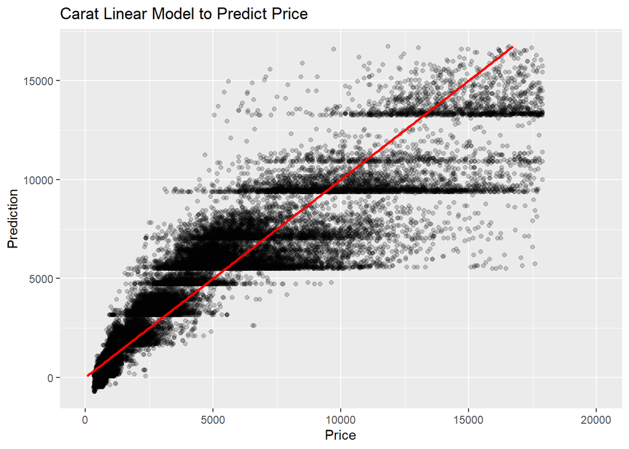

```r
loadPkg("modelr")
df.with.predfin.from.model = add_predictions(diamondsNO_train,modelcarat)
head(df.with.predfin.from.model)
loadPkg("ggplot2")
ggplot(df.with.predfin.from.model,aes(price,pred))+geom_point(aes(price,pred), alpha =0.2)+geom_line(aes(pred), colour="red", size=1) + labs(title = "Carat Linear Model to Predict Price", x = "Price", y = "Prediction") + xlim(c(0, 20000))
```

Carat does very well at the lower prices, but falls apart at the higher ones, so we will be looking to remedy this.

### Multinumeric Linear Model

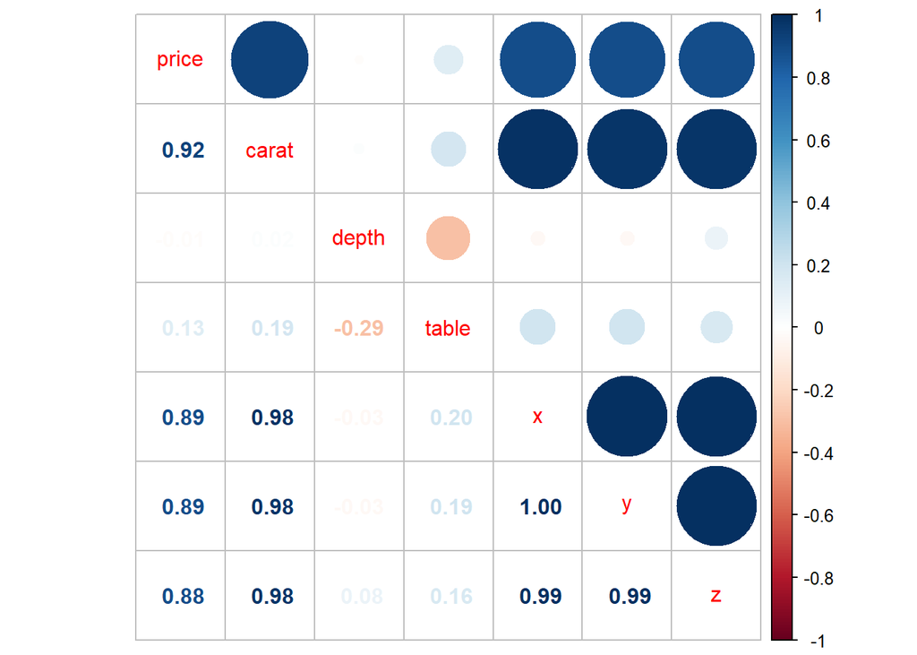

```r
diamondsnum =  subset(diamondsNO, select = c("price", "carat", "depth", "table", "x", "y", "z"))
diamondscor = cor(diamondsnum)
loadPkg("corrplot")
corrplot.mixed(diamondscor)
```

To start off, let’s look at a correlation plot between all the variables. Already, we can see there are going to be some problems in models with multiple numeric variables, as many of them are correlated with each other.

Let’s try to create a linear model using carat and x.

```r
modelcaratx <- lm(price ~ carat+x,data=diamondsNO_train)
tab_model(modelcaratx)
```

|  | price |  |  |
| --- | --- | --- | --- |
| Predictors | Estimates | CI | p |
| (Intercept) | 3922.33 | 3681.96 – 4162.70 | **<0.001** |
| carat | 11563.00 | 11412.77 – 11713.24 | **<0.001** |
| x | -1606.06 | -1668.17 – -1543.94 | **<0.001** |
| Observations | 42373 |  |  |
| R<sup>2</sup> / R<sup>2</sup> adjusted | 0.863 / 0.863 |  |  |

```r
xkablevif(modelcaratx)
```

VIFs of the model

| carat | x |
| --- | --- |
| 25.8 | 25.8 |

As we can see, the model is pretty good, but has extremely high VIF values.

Next let’s try a linear model with carat and table.

```r
modelcarattable <- lm(price ~ carat+table,data=diamondsNO_train)
tab_model(modelcarattable)
```

|  | price |  |  |
| --- | --- | --- | --- |
| Predictors | Estimates | CI | p |
| (Intercept) | 1845.72 | 1474.16 – 2217.28 | **<0.001** |
| carat | 7816.70 | 7785.90 – 7847.51 | **<0.001** |
| table | -72.26 | -78.79 – -65.72 | **<0.001** |
| Observations | 42373 |  |  |
| R<sup>2</sup> / R<sup>2</sup> adjusted | 0.856 / 0.856 |  |  |

```r
xkablevif(modelcarattable)
```

VIFs of the model

| carat | table |
| --- | --- |
| 1.03 | 1.03 |

While this model has low VIF values, it has about the same adjusted r-squared as the carat model, so it is not much of an improvement.

Just for fun, let’s try a model with depth and x.

```r
modeldepthx <- lm(price ~ depth+x,data=diamondsNO_train)
tab_model(modeldepthx)
```

|  | price |  |  |
| --- | --- | --- | --- |
| Predictors | Estimates | CI | p |
| (Intercept) | -16280.56 | -17069.11 – -15492.00 | **<0.001** |
| depth | 40.81 | 28.16 – 53.46 | **<0.001** |
| x | 3082.40 | 3067.24 – 3097.56 | **<0.001** |
| Observations | 42373 |  |  |
| R<sup>2</sup> / R<sup>2</sup> adjusted | 0.789 / 0.789 |  |  |

```r
xkablevif(modeldepthx)
```

VIFs of the model

| depth | x |
| --- | --- |
| 1 | 1 |

This model is not terrible, but it does not beat the carat model, despite the low VIF values.

After researching online, there is not really a good way to fix multicollinearity for a linear model. Most suggestions involve dropping the collinear variables, or increasing the sample size, both of which do not apply in this case. Because of this, we will move away from linear models with multiple numeric variables.

### Numeric + Catergorical Models

Let’s start this section with a simple carat + cut model. We are going to primarily use carat here as our continious variable, because it is was the best single variable model.

```r
modelcaratcut <- lm(price ~ carat+cut, data = diamondsNO_train)
tab_model(modelcaratcut)
```

|  | price |  |  |
| --- | --- | --- | --- |
| Predictors | Estimates | CI | p |
| (Intercept) | -2658.39 | -2692.54 – -2624.23 | **<0.001** |
| carat | 7851.58 | 7821.19 – 7881.96 | **<0.001** |
| cut [linear] | 1101.07 | 1037.53 – 1164.62 | **<0.001** |
| cut [quadratic] | -414.48 | -470.10 – -358.85 | **<0.001** |
| cut [cubic] | 301.32 | 256.17 – 346.47 | **<0.001** |
| cut [4th degree] | 90.96 | 56.65 – 125.26 | **<0.001** |
| Observations | 42373 |  |  |
| R<sup>2</sup> / R<sup>2</sup> adjusted | 0.860 / 0.860 |  |  |

```r
xkablevif(modelcaratcut)
```

VIFs of the model

| carat | cut.C | cut.L | cut.Q | cut^4 |
| --- | --- | --- | --- | --- |
| 1.03 | 2.58 | 3.54 | 2.02 | 1.28 |

Right off the bat this is very promising, its adjusted r-squared beats the carat model by a bit. Let’s try models for clarity and color as well.

```r
modelcaratclarity <- lm(price ~ carat+clarity, data = diamondsNO_train)
tab_model(modelcaratclarity)
```

|  | price |  |  |
| --- | --- | --- | --- |
| Predictors | Estimates | CI | p |
| (Intercept) | -2902.42 | -2930.22 – -2874.62 | **<0.001** |
| carat | 8417.63 | 8390.37 – 8444.89 | **<0.001** |
| clarity [linear] | 3888.00 | 3814.97 – 3961.04 | **<0.001** |
| clarity [quadratic] | -1638.44 | -1708.15 – -1568.73 | **<0.001** |
| clarity [cubic] | 737.81 | 678.30 – 797.31 | **<0.001** |
| clarity [4th degree] | -340.64 | -387.50 – -293.78 | **<0.001** |
| clarity [5th degree] | 198.75 | 161.11 – 236.39 | **<0.001** |
| clarity [6th degree] | 27.97 | -4.48 – 60.41 | 0.091 |
| clarity [7th degree] | 177.98 | 149.53 – 206.43 | **<0.001** |
| Observations | 42373 |  |  |
| R<sup>2</sup> / R<sup>2</sup> adjusted | 0.899 / 0.899 |  |  |

```r
xkablevif(modelcaratclarity)
```

VIFs of the model

| carat | clarity.C | clarity.L | clarity.Q | clarity^4 | clarity^5 | clarity^6 | clarity^7 |
| --- | --- | --- | --- | --- | --- | --- | --- |
| 1.15 | 2.58 | 2.06 | 2.47 | 2.04 | 1.51 | 1.28 | 1.12 |

```r
modelcaratcolor <- lm(price ~ carat+color, data = diamondsNO_train)
tab_model(modelcaratcolor)
```

|  | price |  |  |
| --- | --- | --- | --- |
| Predictors | Estimates | CI | p |
| (Intercept) | -2686.33 | -2715.28 – -2657.39 | **<0.001** |
| carat | 8057.56 | 8027.31 – 8087.80 | **<0.001** |
| color [linear] | 1512.71 | 1466.42 – 1559.01 | **<0.001** |
| color [quadratic] | -717.38 | -759.79 – -674.97 | **<0.001** |
| color [cubic] | 120.28 | 80.54 – 160.02 | **<0.001** |
| color [4th degree] | 70.63 | 34.20 – 107.07 | **<0.001** |
| color [5th degree] | 141.93 | 107.51 – 176.34 | **<0.001** |
| color [6th degree] | -193.19 | -224.41 – -161.97 | **<0.001** |
| Observations | 42373 |  |  |
| R<sup>2</sup> / R<sup>2</sup> adjusted | 0.869 / 0.869 |  |  |

```r
xkablevif(modelcaratcolor)
```

VIFs of the model

| carat | color.C | color.L | color.Q | color^4 | color^5 | color^6 |
| --- | --- | --- | --- | --- | --- | --- |
| 1.1 | 1.29 | 1.23 | 1.21 | 1.17 | 1.06 | 1.03 |

The carat + clarity model is great, with an adjusted r.squared of 0.899. It easily is the best model overall, even beating out the carat model. On top of this, it does not have high VIF values.

Since all three of the variables made a difference, let’s try a carat + color + cut + clarity model.

```r
modelcaratccc = lm(price ~ carat+color+cut+clarity, data = diamondsNO_train)
tab_model(modelcaratccc)
```

|  | price |  |  |
| --- | --- | --- | --- |
| Predictors | Estimates | CI | p |
| (Intercept) | -3620.37 | -3650.79 – -3589.95 | **<0.001** |
| carat | 8854.99 | 8829.24 – 8880.75 | **<0.001** |
| color [linear] | 1854.14 | 1817.56 – 1890.71 | **<0.001** |
| color [quadratic] | -581.79 | -615.17 – -548.40 | **<0.001** |
| color [cubic] | 174.06 | 142.92 – 205.20 | **<0.001** |
| color [4th degree] | 21.76 | -6.79 – 50.31 | 0.135 |
| color [5th degree] | 80.98 | 54.03 – 107.93 | **<0.001** |
| color [6th degree] | -67.32 | -91.83 – -42.82 | **<0.001** |
| cut [linear] | 645.15 | 596.59 – 693.70 | **<0.001** |
| cut [quadratic] | -287.58 | -329.90 – -245.27 | **<0.001** |
| cut [cubic] | 162.22 | 127.96 – 196.48 | **<0.001** |
| cut [4th degree] | 0.79 | -25.20 – 26.78 | 0.953 |
| clarity [linear] | 3949.27 | 3883.11 – 4015.44 | **<0.001** |
| clarity [quadratic] | -1588.44 | -1650.90 – -1525.99 | **<0.001** |
| clarity [cubic] | 695.33 | 642.18 – 748.48 | **<0.001** |
| clarity [4th degree] | -251.16 | -293.01 – -209.30 | **<0.001** |
| clarity [5th degree] | 144.31 | 110.76 – 177.85 | **<0.001** |
| clarity [6th degree] | 15.32 | -13.58 – 44.22 | 0.299 |
| clarity [7th degree] | 96.04 | 70.66 – 121.41 | **<0.001** |
| Observations | 42373 |  |  |
| R<sup>2</sup> / R<sup>2</sup> adjusted | 0.920 / 0.920 |  |  |

```r
xkablevif(modelcaratccc)
```

VIFs of the model

| carat | clarity.C | clarity.L | clarity.Q | clarity^4 | clarity^5 | clarity^6 | clarity^7 | color.C | color.L | color.Q | color^4 | color^5 | color^6 | cut.C | cut.L | cut.Q | cut^4 |
| --- | --- | --- | --- | --- | --- | --- | --- | --- | --- | --- | --- | --- | --- | --- | --- | --- | --- |
| 1.3 | 1.31 | 1.25 | 1.22 | 1.17 | 1.06 | 1.04 | 2.64 | 3.59 | 2.03 | 1.29 | 2.68 | 2.08 | 2.49 | 2.06 | 1.51 | 1.29 | 1.12 |

This model, the C+C+C+C model for short, is outstanding, with low VIF values and an adjusted r-squared of 0.92. This is clearly the best model out of the bunch.

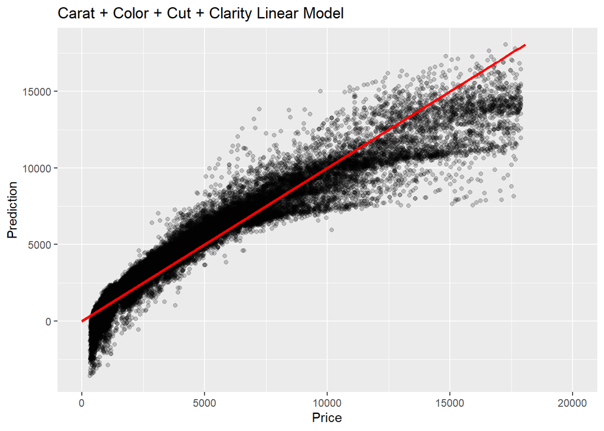

```r
df.with.predfin.from.model <- add_predictions(diamondsNO_train,modelcaratccc)
head(df.with.predfin.from.model)
loadPkg("ggplot2")
ggplot(df.with.predfin.from.model,aes(price,pred))+geom_point(aes(price,pred), alpha =0.2)+geom_line(aes(pred), colour="red", size=1) + labs(title = "Carat + Color + Cut + Clarity Linear Model", x = "Price", y = "Prediction") + xlim(c(0, 20000))
```

Here we can see the best model’s prediction on the train set, performing quite well overall.

### Interaction Terms

Now let’s try adding some interaction terms to the models.

```r
modelcaratccci <- lm(price ~ carat * clarity, data = diamondsNO_train)
tab_model(modelcaratccci)
```

|  | price |  |  |
| --- | --- | --- | --- |
| Predictors | Estimates | CI | p |
| (Intercept) | -2668.06 | -2711.95 – -2624.18 | **<0.001** |
| carat | 8693.10 | 8646.82 – 8739.39 | **<0.001** |
| clarity [linear] | -505.63 | -682.57 – -328.69 | **<0.001** |
| clarity [quadratic] | 334.10 | 159.36 – 508.84 | **<0.001** |
| clarity [cubic] | -767.74 | -913.13 – -622.36 | **<0.001** |
| clarity [4th degree] | 632.10 | 524.03 – 740.16 | **<0.001** |
| clarity [5th degree] | -508.51 | -587.69 – -429.33 | **<0.001** |
| clarity [6th degree] | 203.82 | 140.48 – 267.15 | **<0.001** |
| clarity [7th degree] | -31.76 | -85.74 – 22.23 | 0.249 |
| carat * clarity [linear] | 5430.34 | 5252.07 – 5608.62 | **<0.001** |
| carat * clarity [quadratic] | -861.56 | -1033.69 – -689.43 | **<0.001** |
| carat * clarity [cubic] | 1229.13 | 1079.70 – 1378.57 | **<0.001** |
| carat * clarity [4th degree] | -893.61 | -1015.30 – -771.92 | **<0.001** |
| carat * clarity [5th degree] | 662.43 | 562.84 – 762.03 | **<0.001** |
| carat * clarity [6th degree] | -101.73 | -185.23 – -18.22 | **0.017** |
| carat * clarity [7th degree] | 294.95 | 227.73 – 362.16 | **<0.001** |
| Observations | 42373 |  |  |
| R<sup>2</sup> / R<sup>2</sup> adjusted | 0.910 / 0.910 |  |  |

```r
xkablevif(modelcaratccci)
```

VIFs of the model

| carat | carat:clarity.C | carat:clarity.L | carat:clarity.Q | carat:clarity^4 | carat:clarity^5 | carat:clarity^6 | carat:clarity^7 | clarity.C | clarity.L | clarity.Q | clarity^4 | clarity^5 | clarity^6 | clarity^7 |
| --- | --- | --- | --- | --- | --- | --- | --- | --- | --- | --- | --- | --- | --- | --- |
| 3.73 | 17 | 14.5 | 16.5 | 12.2 | 7.49 | 5.48 | 4.51 | 14.2 | 11.7 | 13.7 | 13.8 | 10.4 | 7.64 | 5.21 |

Here we can the carat * clarity model. This model has extremely high VIF values, and does not beat the best model.

```r
modelcaratccci2 = lm(price ~ carat + (color+cut+clarity)^2, data = diamondsNO_train)
tab_model(modelcaratccci2)
```

|  | price |  |  |
| --- | --- | --- | --- |
| Predictors | Estimates | CI | p |
| (Intercept) | -3542.64 | -3586.28 – -3499.01 | **<0.001** |
| carat | 8850.76 | 8825.05 – 8876.46 | **<0.001** |
| color [linear] | 2104.57 | 2026.67 – 2182.48 | **<0.001** |
| color [quadratic] | -280.05 | -351.73 – -208.36 | **<0.001** |
| color [cubic] | 145.63 | 79.07 – 212.18 | **<0.001** |
| color [4th degree] | 86.50 | 24.87 – 148.12 | **0.006** |
| color [5th degree] | 107.45 | 52.56 – 162.34 | **<0.001** |
| color [6th degree] | -38.74 | -86.62 – 9.14 | 0.113 |
| cut [linear] | 643.42 | 535.74 – 751.09 | **<0.001** |
| cut [quadratic] | -286.81 | -380.55 – -193.06 | **<0.001** |
| cut [cubic] | 185.53 | 116.81 – 254.26 | **<0.001** |
| cut [4th degree] | -16.97 | -66.54 – 32.60 | 0.502 |
| clarity [linear] | 4164.04 | 4024.37 – 4303.70 | **<0.001** |
| clarity [quadratic] | -1305.67 | -1430.40 – -1180.94 | **<0.001** |
| clarity [cubic] | 794.63 | 678.63 – 910.63 | **<0.001** |
| clarity [4th degree] | -187.93 | -300.79 – -75.06 | **0.001** |
| clarity [5th degree] | 122.26 | 23.69 – 220.84 | **0.015** |
| clarity [6th degree] | 27.70 | -48.00 – 103.40 | 0.473 |
| clarity [7th degree] | 89.30 | 34.44 – 144.15 | **0.001** |
| color [linear] * cut [linear] | 3.06 | -156.57 – 162.68 | 0.970 |
| color [quadratic] * cut [linear] | -73.99 | -221.19 – 73.21 | 0.325 |
| color [cubic] * cut [linear] | 248.04 | 105.77 – 390.32 | **0.001** |
| color [4th degree] * cut [linear] | 30.80 | -109.69 – 171.30 | 0.667 |
| color [5th degree] * cut [linear] | 18.16 | -107.81 – 144.14 | 0.777 |
| color [6th degree] * cut [linear] | -43.01 | -156.93 – 70.90 | 0.459 |
| color [linear] * cut [quadratic] | -116.87 | -256.15 – 22.40 | 0.100 |
| color [quadratic] * cut [quadratic] | 75.50 | -53.17 – 204.16 | 0.250 |
| color [cubic] * cut [quadratic] | -184.27 | -308.51 – -60.03 | **0.004** |
| color [4th degree] * cut [quadratic] | 72.30 | -49.91 – 194.52 | 0.246 |

[output cut: 86 more lines]

```r
xkablevif(modelcaratccci2)
```

VIFs of the model

| carat | clarity.C | clarity.L | clarity.Q | clarity^4 | clarity^5 | clarity^6 | clarity^7 | color.C | color.C:clarity.C | color.C:clarity.L | color.C:clarity.Q | color.C:clarity^4 | color.C:clarity^5 | color.C:clarity^6 | color.C:clarity^7 | color.C:cut.C | color.C:cut.L | color.C:cut.Q | color.C:cut^4 | color.L | color.L:clarity.C | color.L:clarity.L | color.L:clarity.Q | color.L:clarity^4 | color.L:clarity^5 | color.L:clarity^6 | color.L:clarity^7 | color.L:cut.C | color.L:cut.L | … |
| --- | --- | --- | --- | --- | --- | --- | --- | --- | --- | --- | --- | --- | --- | --- | --- | --- | --- | --- | --- | --- | --- | --- | --- | --- | --- | --- | --- | --- | --- | --- |
| 1.33 | 6.11 | 5.89 | 5.69 | 5.61 | 4.53 | 4.05 | 13.3 | 18.1 | 8.39 | 4.8 | 12.2 | 8.52 | 12.1 | 15.3 | 13.4 | 9.05 | 5.37 | 5.31 | 5.33 | 5.25 | 5.99 | 4.83 | 4.79 | 4.35 | 4.34 | 4.17 | 4.67 | 3.83 | 3.71 | … |

This model, the carat + (color+cut+clarity)^2 model, actually does have a higher adjusted r-squared than the C+C+C+C model, at 0.922. However, it also has high VIF values, indicating it should not be used.

```r
modelcaratccci3 = lm(price ~ (carat + clarity)^2, data = diamondsNO_train)
tab_model(modelcaratccci3)
```

|  | price |  |  |
| --- | --- | --- | --- |
| Predictors | Estimates | CI | p |
| (Intercept) | -2668.06 | -2711.95 – -2624.18 | **<0.001** |
| carat | 8693.10 | 8646.82 – 8739.39 | **<0.001** |
| clarity [linear] | -505.63 | -682.57 – -328.69 | **<0.001** |
| clarity [quadratic] | 334.10 | 159.36 – 508.84 | **<0.001** |
| clarity [cubic] | -767.74 | -913.13 – -622.36 | **<0.001** |
| clarity [4th degree] | 632.10 | 524.03 – 740.16 | **<0.001** |
| clarity [5th degree] | -508.51 | -587.69 – -429.33 | **<0.001** |
| clarity [6th degree] | 203.82 | 140.48 – 267.15 | **<0.001** |
| clarity [7th degree] | -31.76 | -85.74 – 22.23 | 0.249 |
| carat * clarity [linear] | 5430.34 | 5252.07 – 5608.62 | **<0.001** |
| carat * clarity [quadratic] | -861.56 | -1033.69 – -689.43 | **<0.001** |
| carat * clarity [cubic] | 1229.13 | 1079.70 – 1378.57 | **<0.001** |
| carat * clarity [4th degree] | -893.61 | -1015.30 – -771.92 | **<0.001** |
| carat * clarity [5th degree] | 662.43 | 562.84 – 762.03 | **<0.001** |
| carat * clarity [6th degree] | -101.73 | -185.23 – -18.22 | **0.017** |
| carat * clarity [7th degree] | 294.95 | 227.73 – 362.16 | **<0.001** |
| Observations | 42373 |  |  |
| R<sup>2</sup> / R<sup>2</sup> adjusted | 0.910 / 0.910 |  |  |

```r
xkablevif(modelcaratccci3)
```

VIFs of the model

| carat | carat:clarity.C | carat:clarity.L | carat:clarity.Q | carat:clarity^4 | carat:clarity^5 | carat:clarity^6 | carat:clarity^7 | clarity.C | clarity.L | clarity.Q | clarity^4 | clarity^5 | clarity^6 | clarity^7 |
| --- | --- | --- | --- | --- | --- | --- | --- | --- | --- | --- | --- | --- | --- | --- |
| 3.73 | 17 | 14.5 | 16.5 | 12.2 | 7.49 | 5.48 | 4.51 | 14.2 | 11.7 | 13.7 | 13.8 | 10.4 | 7.64 | 5.21 |

And lastly, this model does not beat the best model either.

### Feature Selection

Usually, when one is building a linear model, they start with feature selection in order to try to come up with the best model to use. However, due to the limited number of variables, it was easier to start with a model and then use the feature selection to confirm our findings.

Let’s start with an exhaustive search.

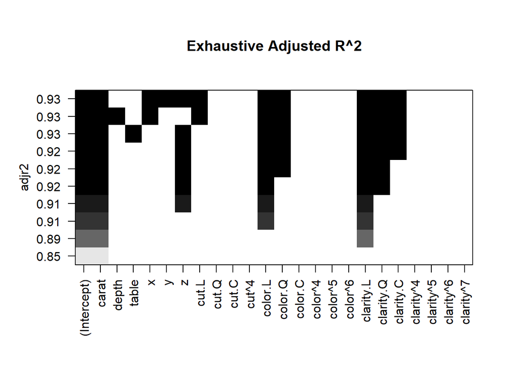

```r
loadPkg("leaps")
reg.best10 = regsubsets(price~. , data = diamondsNO_train, nvmax = 10, nbest = 1, method = "exhaustive")
plot(reg.best10, scale = "adjr2", main = "Exhaustive Adjusted R^2")
```

Here we can see that the exhaustive model begins to prove our suspicions. Carat is the best single variable for the model, followed by traits of clarity and color. This makes sense, as our best model uses these as predictors. It should be noted that using other criteria, like r-squared, BIC, or Cp created the same results.

Now let’s try forward selection.

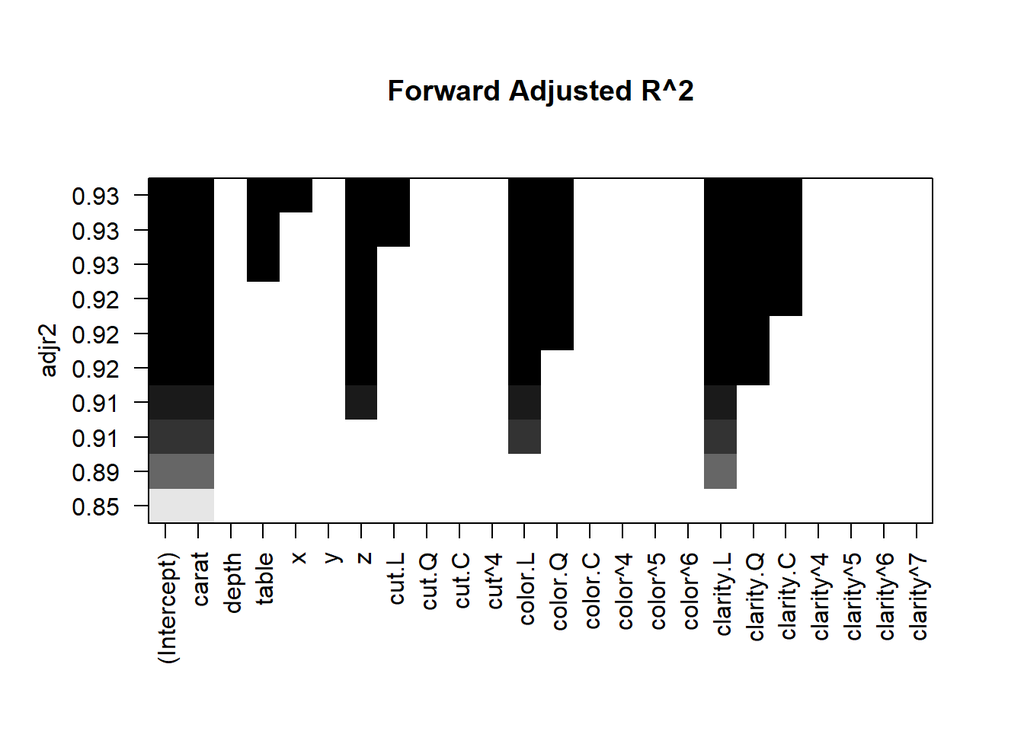

```r
reg.forward10 <- regsubsets(price~., data = diamondsNO_train, nvmax = 10, nbest = 1, method = "forward")
plot(reg.forward10, scale = "adjr2", main = "Forward Adjusted R^2")
```

This feature selection process is nearly identical to the last one. Let’s try both backward and segrep feature selection

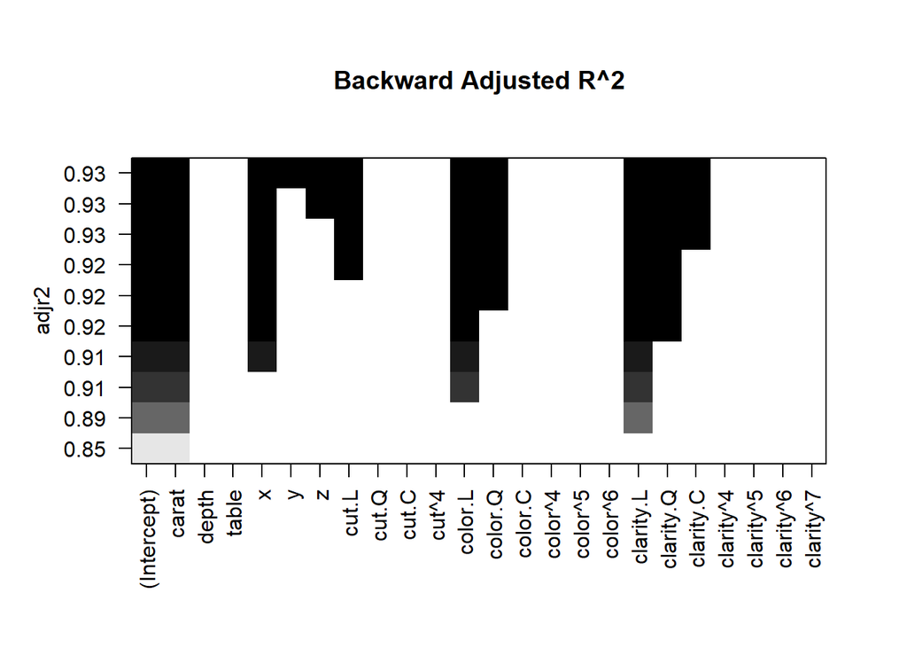

```r
reg.forward10 <- regsubsets(price~., data = diamondsNO_train, nvmax = 10, nbest = 1, method = "backward")
plot(reg.forward10, scale = "adjr2", main = "Backward Adjusted R^2")
```

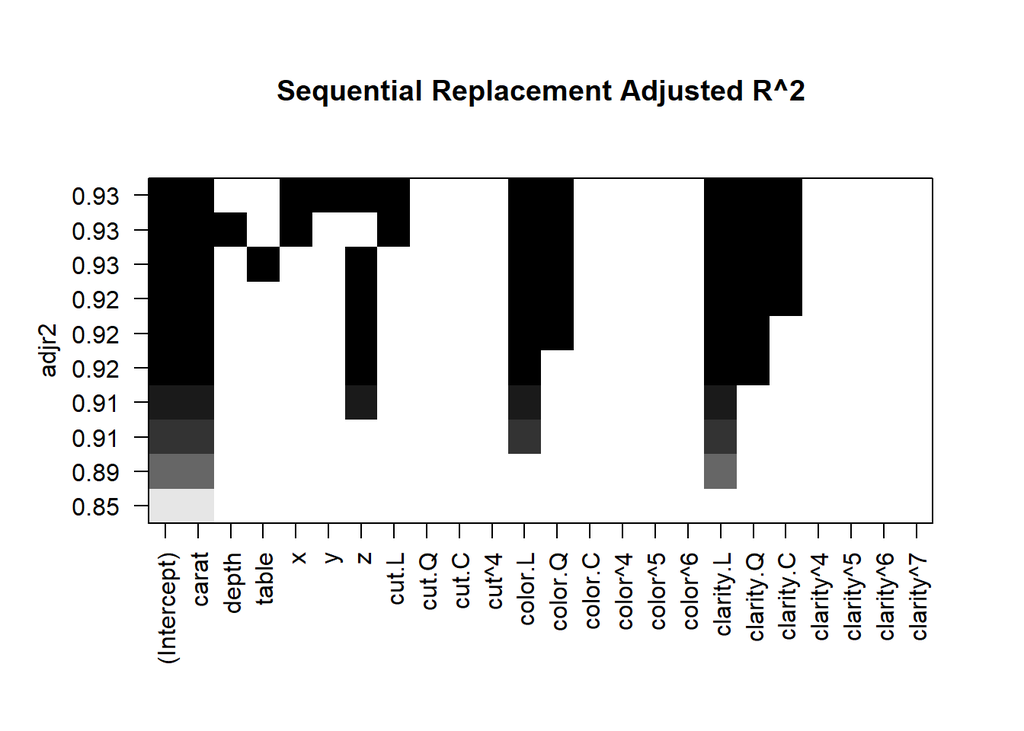

```r
reg.forward10 <- regsubsets(price~., data = diamondsNO_train, nvmax = 10, nbest = 1, method = "seqrep")
plot(reg.forward10, scale = "adjr2", main = "Sequential Replacement Adjusted R^2")
```

In all of these feature selection techniques, carat is the most important, followed by clarity and color. It should be noted that despite cut making a difference in the C+C+C+C model, it did not show up much here.

Let’s bring the C+C+C+C model into the testing phase.

### Testing the Best Model

Let’s test the accuracy of the C+C+C+C model on the test data. While the model was not trained on the train data, we can still remake the same model using the same formula on the test data. Let’s start by remaking the C+C+C+C model on the test data to check its adjusted r-squared.

```r
modelcaratcccT = lm(price ~ carat+color+cut+clarity, data = diamondsNO_test)
tab_model(modelcaratcccT)
```

|  | price |  |  |
| --- | --- | --- | --- |
| Predictors | Estimates | CI | p |
| (Intercept) | -3635.29 | -3695.58 – -3575.00 | **<0.001** |
| carat | 8852.52 | 8800.86 – 8904.18 | **<0.001** |
| color [linear] | 1892.46 | 1819.95 – 1964.97 | **<0.001** |
| color [quadratic] | -634.77 | -700.48 – -569.06 | **<0.001** |
| color [cubic] | 148.28 | 86.52 – 210.04 | **<0.001** |
| color [4th degree] | -7.09 | -63.95 – 49.77 | 0.807 |
| color [5th degree] | 59.04 | 5.15 – 112.93 | **0.032** |
| color [6th degree] | -19.15 | -67.89 – 29.58 | 0.441 |
| cut [linear] | 627.51 | 533.03 – 721.98 | **<0.001** |
| cut [quadratic] | -255.30 | -337.72 – -172.88 | **<0.001** |
| cut [cubic] | 129.22 | 61.49 – 196.95 | **<0.001** |
| cut [4th degree] | 6.98 | -44.84 – 58.80 | 0.792 |
| clarity [linear] | 3837.68 | 3707.96 – 3967.39 | **<0.001** |
| clarity [quadratic] | -1577.87 | -1700.29 – -1455.45 | **<0.001** |
| clarity [cubic] | 671.19 | 566.96 – 775.41 | **<0.001** |
| clarity [4th degree] | -197.69 | -280.49 – -114.90 | **<0.001** |
| clarity [5th degree] | 164.38 | 97.65 – 231.12 | **<0.001** |
| clarity [6th degree] | 70.60 | 13.25 – 127.95 | **0.016** |
| clarity [7th degree] | 149.95 | 99.04 – 200.85 | **<0.001** |
| Observations | 10557 |  |  |
| R<sup>2</sup> / R<sup>2</sup> adjusted | 0.920 / 0.920 |  |  |

```r
xkablevif(modelcaratcccT)
```

VIFs of the model

| carat | clarity.C | clarity.L | clarity.Q | clarity^4 | clarity^5 | clarity^6 | clarity^7 | color.C | color.L | color.Q | color^4 | color^5 | color^6 | cut.C | cut.L | cut.Q | cut^4 |
| --- | --- | --- | --- | --- | --- | --- | --- | --- | --- | --- | --- | --- | --- | --- | --- | --- | --- |
| 1.29 | 1.3 | 1.23 | 1.2 | 1.17 | 1.06 | 1.04 | 2.55 | 3.46 | 1.98 | 1.28 | 2.58 | 2 | 2.42 | 2 | 1.51 | 1.29 | 1.13 |

We can see that the model performs just as well when using the test data as it did on the training data. It also has no high VIF values.

The adjusted r-squared is 0.92, meaning that roughly 92% of the variation in price can be explained by our model.

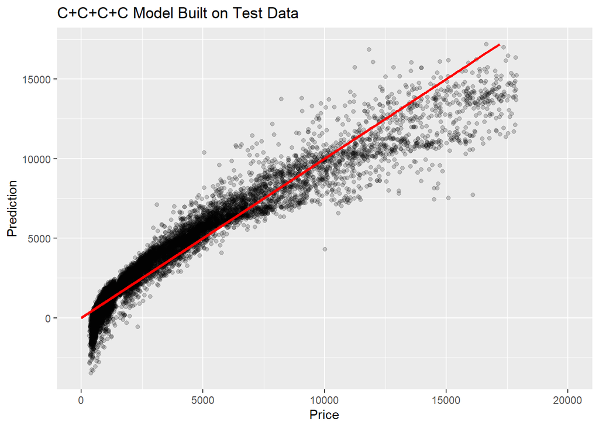

```r
df.with.predfin.from.model <- add_predictions(diamondsNO_test,modelcaratcccT)
head(df.with.predfin.from.model)
loadPkg("ggplot2")
ggplot(df.with.predfin.from.model,aes(price,pred))+geom_point(aes(price,pred), alpha =0.2)+geom_line(aes(pred), colour="red", size=1) + labs(title = "C+C+C+C Model Built on Test Data", x = "Price", y = "Prediction") + xlim(c(0, 20000))
```

Here we can see how well the model performs when predicting on the test data. It performs quite well.

Lastly, let’s look at one other metric of the linear model on the test data. The mean absolute error of the model is 764.016. This means that on average, the model misses the price by plus or minus 764.016. This may seem high, but it is largely due to a few outliers. This can be seen in the residual plot.

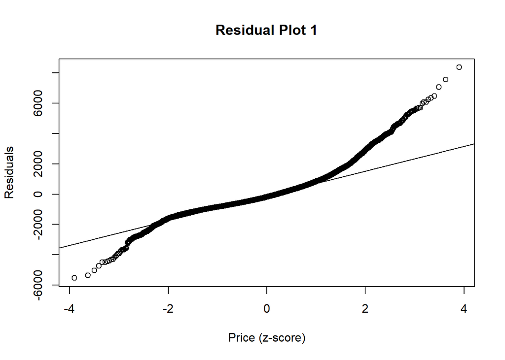

```r
res <- resid(modelcaratcccT)
qqnorm(res, ann = FALSE)
qqline(res)
title("Residual Plot 1", xlab="Price (z-score)", ylab="Residuals")
```

Our model performs really well at middle price values, but struggles at higher and lower prices.

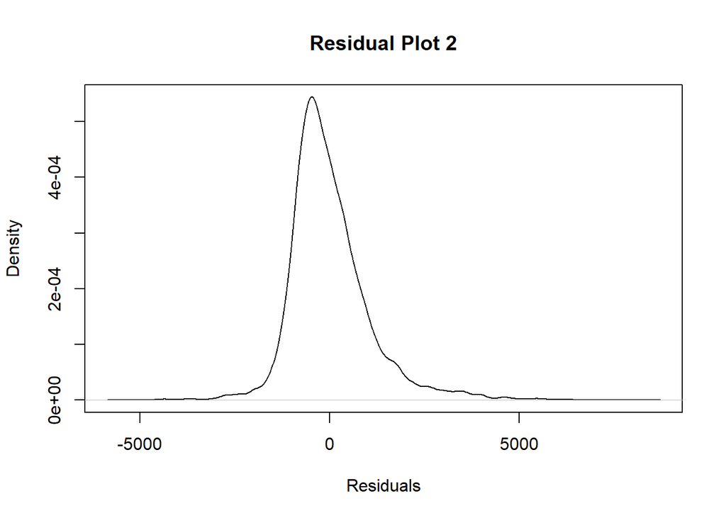

```r
plot(density(res), ann = FALSE)
title("Residual Plot 2", xlab="Residuals", ylab="Density")
```

Here we can see again that the model performs well overall, but has a lot of outliers.

Overall, our model performed quite well on the test data. In the future, we will definitely look into techniques so the model can be more accurate at higher and lower prices.

## PCR modeling to predict price

For PCR modeling, we first subset all the continuous variables from the original dataframe. All the data is scaled and centered already, so we can perform PCR.

```r
diamondscont <- subset(diamondsNO_SC_train, select = c ("carat", "depth", "table", "price", "x", "y", "z"))
```

Now, we can obtain the Principal components of our desired model.

```r
pcrcomp <- prcomp(diamondscont, scale = TRUE)
summary(pcrcomp)
```

```
## Importance of components:
##                          PC1   PC2    PC3   PC4     PC5     PC6     PC7
## Standard deviation     2.201 1.131 0.8335 0.401 0.13603 0.03946 0.03568
## Proportion of Variance 0.692 0.183 0.0993 0.023 0.00264 0.00022 0.00018
## Cumulative Proportion  0.692 0.875 0.9740 0.997 0.99960 0.99982 1.00000
```

```r
pcrcomp$rotation
```

```
##            PC1       PC2      PC3     PC4     PC5       PC6       PC7
## carat  0.45069 -0.033250  0.00844  0.0108 -0.8914  0.005288 -0.030208
## depth -0.00286 -0.731032 -0.67432  0.0397  0.0194 -0.094506 -0.000426
## table  0.09889  0.675287 -0.72842  0.0570  0.0187 -0.001370 -0.003956
## price  0.42352 -0.037577  0.09657  0.8709  0.2266  0.000946  0.011574
## x      0.45077  0.000298  0.04112 -0.2845  0.1980 -0.391475  0.722306
## y      0.45068 -0.000870  0.04941 -0.2790  0.2459 -0.423160 -0.690708
## z      0.44880 -0.084032 -0.03432 -0.2791  0.2315  0.811616 -0.011597
```

From the above Principal components we can see that PC1 is affected by x and carat the most. We can build the model with one or more Principal components depending on the variance in price explained. In our case, we are trying to eliminate all but one continuous variables since they are collinear. Let us run a principal regression model from the Pls library and see the results. By performing PCR we can tackle the problem of multi-collinearity. We need to keep in mind the RMSE values while evaluating the model since the VIF checks will show 1 or less than 1 for data that is scaled.

```r
library(pls)
pcr_model <- pcr(price~., data = diamondscont,ncomp=6, validation = "CV")
summary(pcr_model)
```

```
## Data:    X dimension: 42373 6
##  Y dimension: 42373 1
## Fit method: svdpc
## Number of components considered: 6
##
## VALIDATION: RMSEP
## Cross-validated using 10 random segments.
##        (Intercept)  1 comps  2 comps  3 comps  4 comps  5 comps  6 comps
## CV           1.002   0.4416   0.4390   0.4318   0.3647   0.3646   0.3623
## adjCV        1.002   0.4416   0.4389   0.4318   0.3647   0.3648   0.3623
##
## TRAINING: % variance explained
##        1 comps  2 comps  3 comps  4 comps  5 comps  6 comps
## X        66.84    88.06    99.49    99.95    99.98   100.00
## price    80.57    80.80    81.42    86.75    86.75    86.92
```

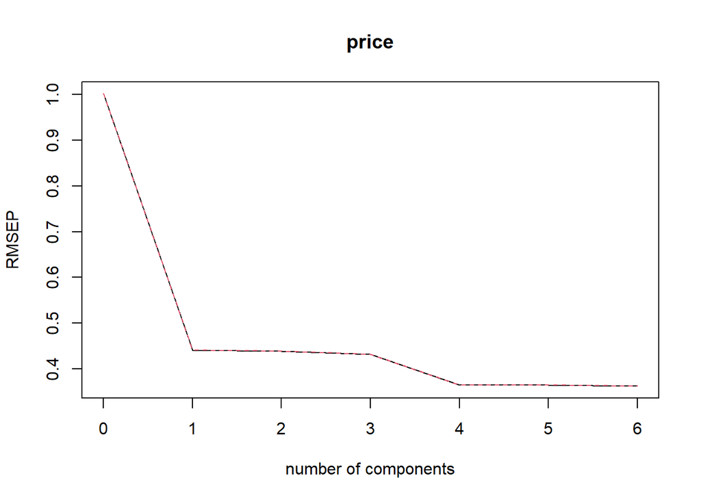

```r
validationplot(pcr_model)
```

If we wish to select one of the continuous variables since they are all collinear, we can choose the PC1 which is mostly affected by the carat of the diamond.

We will try to build a linear model with one variable from the PC1. x, y, z and carat have highest probabilities.

### Linear regression model with 1 component

```r
linear_model_pcr_1a = lm(price~ x , data= diamondsNO_train)
tab_model(linear_model_pcr_1a)
```

|  | price |  |  |
| --- | --- | --- | --- |
| Predictors | Estimates | CI | p |
| (Intercept) | -13752.95 | -13840.94 – -13664.96 | **<0.001** |
| x | 3081.05 | 3065.90 – 3096.21 | **<0.001** |
| Observations | 42373 |  |  |
| R<sup>2</sup> / R<sup>2</sup> adjusted | 0.789 / 0.789 |  |  |

```r
linear_model_pcr_1b = lm(price~ y   , data= diamondsNO_train)
tab_model(linear_model_pcr_1b)
```

|  | price |  |  |
| --- | --- | --- | --- |
| Predictors | Estimates | CI | p |
| (Intercept) | -13910.37 | -13998.48 – -13822.26 | **<0.001** |
| y | 3107.21 | 3092.03 – 3122.38 | **<0.001** |
| Observations | 42373 |  |  |
| R<sup>2</sup> / R<sup>2</sup> adjusted | 0.792 / 0.792 |  |  |

```r
linear_model_pcr_1c = lm(price~ z   , data= diamondsNO_train)
tab_model(linear_model_pcr_1c)
```

|  | price |  |  |
| --- | --- | --- | --- |
| Predictors | Estimates | CI | p |
| (Intercept) | -13680.15 | -13769.72 – -13590.59 | **<0.001** |
| z | 4968.46 | 4943.47 – 4993.45 | **<0.001** |
| Observations | 42373 |  |  |
| R<sup>2</sup> / R<sup>2</sup> adjusted | 0.782 / 0.782 |  |  |

```r
linear_model_pcr_1d = lm(price~ depth   , data= diamondsNO_train)
tab_model(linear_model_pcr_1d)
```

|  | price |  |  |
| --- | --- | --- | --- |
| Predictors | Estimates | CI | p |
| (Intercept) | 5652.93 | 3950.63 – 7355.24 | **<0.001** |
| depth | -29.88 | -57.45 – -2.32 | **0.034** |
| Observations | 42373 |  |  |
| R<sup>2</sup> / R<sup>2</sup> adjusted | 0.000 / 0.000 |  |  |

```r
linear_model_pcr_1e = lm(price~ table   , data= diamondsNO_train)
tab_model(linear_model_pcr_1e)
```

|  | price |  |  |
| --- | --- | --- | --- |
| Predictors | Estimates | CI | p |
| (Intercept) | -9420.59 | -10385.13 – -8456.05 | **<0.001** |
| table | 230.39 | 213.61 – 247.18 | **<0.001** |
| Observations | 42373 |  |  |
| R<sup>2</sup> / R<sup>2</sup> adjusted | 0.017 / 0.017 |  |  |

```r
linear_model_pcr_1f = lm(price~ carat   , data= diamondsNO_train)
tab_model(linear_model_pcr_1f)
```

|  | price |  |  |
| --- | --- | --- | --- |
| Predictors | Estimates | CI | p |
| (Intercept) | -2254.20 | -2281.73 – -2226.67 | **<0.001** |
| carat | 7754.44 | 7723.98 – 7784.90 | **<0.001** |
| Observations | 42373 |  |  |
| R<sup>2</sup> / R<sup>2</sup> adjusted | 0.855 / 0.855 |  |  |

We can see from the above models that if we have to choose one variable to best explain the variation it price, it has to be the carat of the diamond because it has the highest adjusted r squared value among the other variables.

### Testing the Best Model

Let’s now test the accuracy of the best linear model, the only carat model, from the PCR section on the test data. We again will remake the model on the test data.

```r
modelcaratT = lm(price ~ carat, data = diamondsNO_test)
tab_model(modelcaratT)
```

|  | price |  |  |
| --- | --- | --- | --- |
| Predictors | Estimates | CI | p |
| (Intercept) | -2281.17 | -2337.00 – -2225.34 | **<0.001** |
| carat | 7763.54 | 7701.97 – 7825.11 | **<0.001** |
| Observations | 10557 |  |  |
| R<sup>2</sup> / R<sup>2</sup> adjusted | 0.853 / 0.853 |  |  |

The model performs well again here when using the test data.

The adjusted r-squared is 0.853, meaning that roughly 85% of the variation in price can be explained by our model.

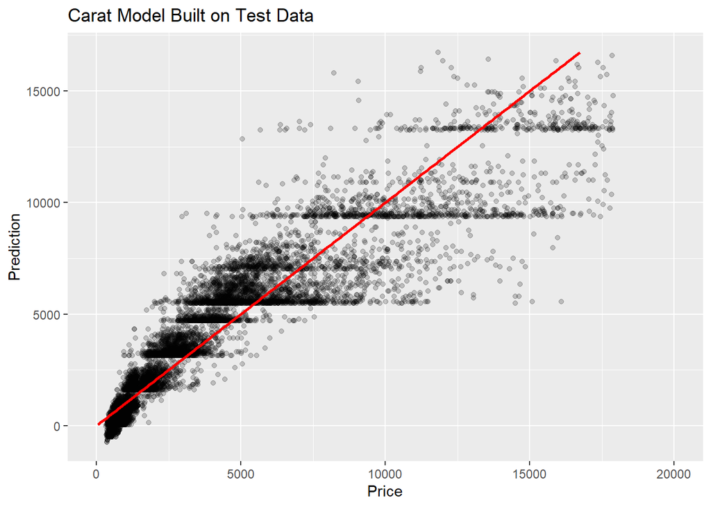

```r
df.with.predfin.from.model1 <- add_predictions(diamondsNO_test,modelcaratT)
head(df.with.predfin.from.model1)
loadPkg("ggplot2")
ggplot(df.with.predfin.from.model1,aes(price,pred))+geom_point(aes(price,pred), alpha =0.2)+geom_line(aes(pred), colour="red", size=1) + labs(title = "Carat Model Built on Test Data", x = "Price", y = "Prediction") + xlim(c(0, 20000))
```

Here we can see how well the model performs when predicting on the test data. It performs well, but misses some of the higher priced diamonds.

Let’s again look at the mean absolute error of the model, which is 972.983. This means that on average, the model misses the price by plus or minus 972.983.

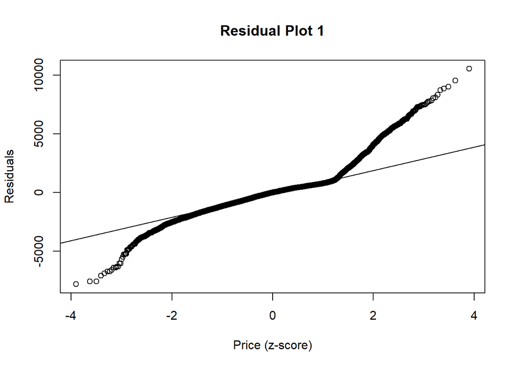

```r
res1 <- resid(modelcaratT)
qqnorm(res1, ann = FALSE)
qqline(res1)
title("Residual Plot 1", xlab="Price (z-score)", ylab="Residuals")
```

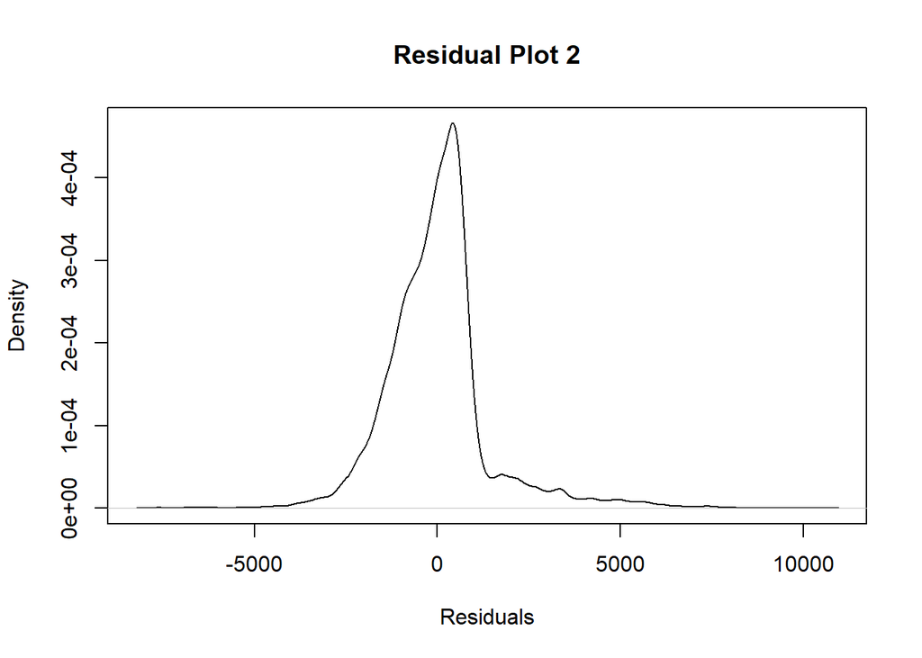

```r
plot(density(res1), ann = FALSE)
title("Residual Plot 2", xlab="Residuals", ylab="Density")
```

Here we can see that the model definitely struggles with higher prices, often being very far off.

For a single variable model, it performs quite well on the test data.

## Random Forest Classification to predict cut

In this section we will be using the Random Forest model to build a classification model to be able to effectively classify diamonds into ‘Fair’, ‘Good’, ‘Very Good’, ‘Premium’, ‘Ideal’ diamond cuts, using the base features.

Prior to Random Forest Classification, Multi-nomial Logistic regression had been used but a very low accuracy score was found.

In this section, we will not be using price to guess diamond cuts, as when workers cut diamonds they do not know the price. All other variables will be included.

### Multinomial Logistic Regression

Before we dive into Random Forest Regression, lets perform a multinomial Logistic Regression and take a look at the accuracy score.

```r
library(randomForest)
require(caTools)
library(MASS)
require(nnet)
diamondsNO_train1 <- subset(diamondsNO_train, select = c ("carat", "depth", "table", "x", "y", "z", "cut", "color", "clarity"))
diamondsNO_test1 <- subset(diamondsNO_test, select = c ("carat", "depth", "table", "x", "y", "z", "cut", "color", "clarity"))
```

```r
# Training the multinomial model
multinom_model <- multinom(cut ~ ., data = diamondsNO_train1)

# Checking the model
summary(multinom_model)

# Predicting the values for train dataset
classPredicted <- predict(multinom_model, newdata = diamondsNO_test1, "class")

# Confusion matrix
library(caret)
cmlogit=confusionMatrix(diamondsNO_test1$cut,classPredicted)
cmlogit
```

Logistic Regression has an accuracy score of 66.42%.

### Random Forest Regression

With Logsitic regression performing poorly, we will test Random Forest Regression.

First, we tune the Random Forest Model to get the best `mtry` (number of variables sampled at each split).

```
## mtry = 2  OOB error = 22.92%
## Searching left ...
## mtry = 4     OOB error = 22.04%
## 0.0384 0.05
## Searching right ...
## mtry = 1     OOB error = 25.92%
## -0.131 0.05
```

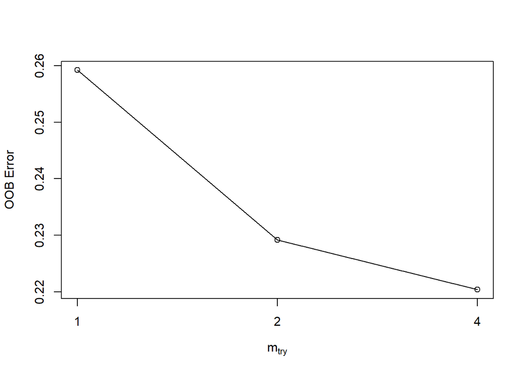

```r
# Tuning Random Forest to get the best mtry (number of variables random sampled as candidates at each split)
tune= tuneRF(diamondsNO_train1[,-7],diamondsNO_trainCutLabel, stepFactor = 0.5, plot=TRUE,
             ntreeTry=75,trace=TRUE, improve=0.05)
```

Note: `mtry` is the number of predictors sampled for splitting at each node.

The chart above helps us choose the best `mtry` to get a minimal Out of Bag Error. Obviously, 4 is the best `mtry` with around 22% OOB error.

```r
rf<- randomForest(cut~ .,data=diamondsNO_train1, mtry=4, ntree=75) #fitting RandomForest Classification
pred = predict(rf, newdata=diamondsNO_test1[,-7]) # Prediction on test set
cm=confusionMatrix(diamondsNO_test1$cut,pred) #confusion matrix
print(rf)
```

```
##
## Call:
##  randomForest(formula = cut ~ ., data = diamondsNO_train1, mtry = 4,      ntree = 75)
##                Type of random forest: classification
##                      Number of trees: 75
## No. of variables tried at each split: 4
##
##         OOB estimate of  error rate: 22.2%
## Confusion matrix:
##           Fair Good Very Good Premium Ideal class.error
## Fair       746   72        22      27    11      0.1503
## Good        92 2724       841     141    65      0.2948
## Very Good    8  648      5327    1554  2052      0.4445
## Premium      1   40      1007    8771  1146      0.2001
## Ideal        9   35       945     698 15391      0.0988
```

The random forest classifier has been modeled with mtry as 4 and ntree as 75.

```r
xkabledply(cm$table,title="Confusion Matrix")
```

Confusion Matrix

|  | Fair | Good | Very Good | Premium | Ideal |
| --- | --- | --- | --- | --- | --- |
| Fair | 195 | 20 | 2 | 12 | 2 |
| Good | 20 | 668 | 229 | 21 | 13 |
| Very Good | 4 | 126 | 1351 | 414 | 495 |
| Premium | 1 | 11 | 264 | 2074 | 311 |
| Ideal | 3 | 7 | 234 | 150 | 3930 |

```r
cm$overall
```

```
##       Accuracy          Kappa  AccuracyLower  AccuracyUpper   AccuracyNull
##       7.78e-01       6.83e-01       7.70e-01       7.86e-01       4.50e-01
## AccuracyPValue  McnemarPValue
##       0.00e+00       2.43e-43
```

The confusion matrix is seen above. Also, we get an accuracy score of 77.844% for the test dataset.

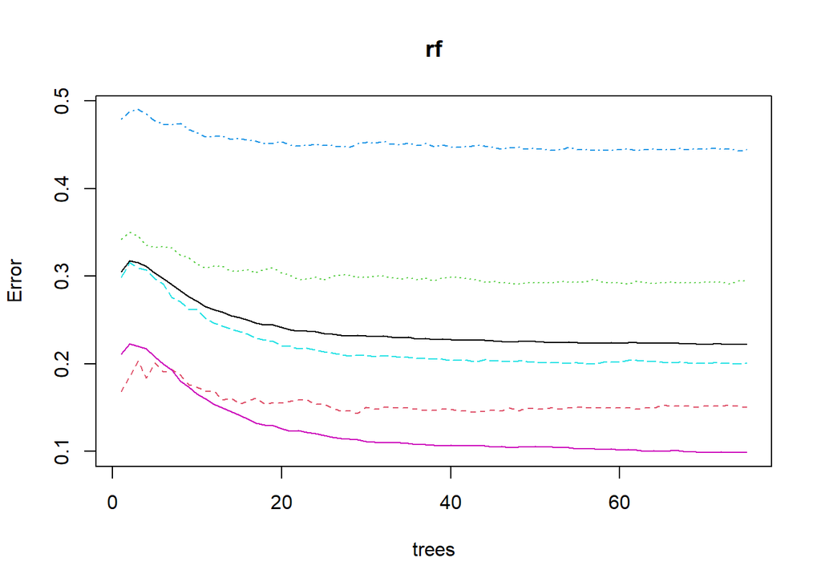

```r
plot(rf)
```

The graph above shows that as the trees increases the Out of Bag Error reduces. While a larger size of trees greater than 75 does not reduce the out of bag error significantly.

```r
round(importance(rf), 2)
```

```
##         MeanDecreaseGini
## carat               1612
## depth               7220
## table               8389
## x                   4043
## y                   3810
## z                   2200
## color               1422
## clarity             1321
```

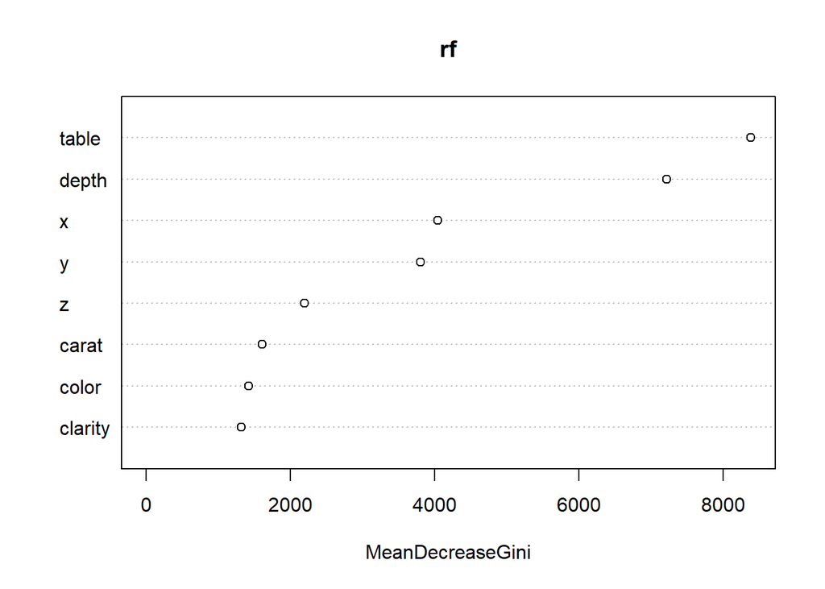

```r
# Mean Decrease in Gini is the average (mean) of a variable's total decrease in node impurity
varImpPlot(rf)
```

The mean decrease in Gini coefficient is a measure of how each variable contributes to the homogeneity of the nodes and leaves in the resulting random forest. The higher the value of mean decrease Gini score, the higher the importance of the variable in the model.

In the above chart, `table` and `depth` have the highest importance in the Random Forest model.

```r
diamondsNO_train2= diamondsNO_train1[,c(1, 2,3,4,5, 6,7,8)]
diamondsNO_test2= diamondsNO_test1[,c(1, 2,3,4,5, 6,7,8)]

rf2<- randomForest(cut~ .,data=diamondsNO_train2,mtry=4, ntree=75) #fitting RandomForest Classification
pred2 = predict(rf2, newdata=diamondsNO_test2[,-7]) # Prediction on test set
cm2=confusionMatrix(diamondsNO_test2$cut,pred2) #confusion matrix
print(rf2)
```

[output not shown]

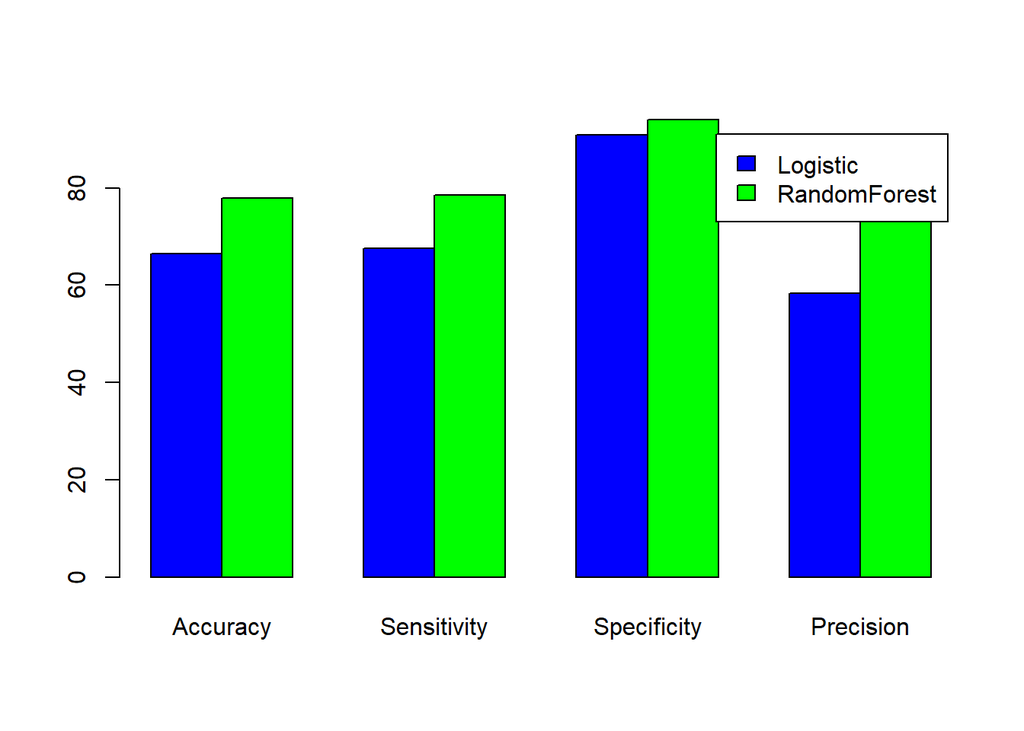

```r
check= data.frame()
# c('accuracy','precision','sensitivity','specificity')
check=rbind(check,c(round((sum(diag(cmlogit$table))/sum(cmlogit$table))*100,2)))
check=rbind(check,c(round((sum(diag(cm$table))/sum(cm$table))*100,2)))
rownames(check)=c('logistic','random forest')
colnames(check)=c("Accuracy Score")
check$AverageSensitiviy=c((sum(cmlogit$byClass[1:5])/5)*100,(sum(cm$byClass[1:5])/5)*100)
check$AverageSpecificity=c((sum(cmlogit$byClass[6:10])/5)*100,(sum(cm$byClass[6:10])/5)*100)
check$AveragePrecision=c((sum(cmlogit$byClass[21:25])/5)*100,(sum(cm$byClass[21:25])/5)*100)

barplot(height=as.matrix(check),beside=TRUE,names.arg = c("Accuracy","Sensitivity","Specificity","Precision"),legend.text = c("Logistic","RandomForest"),col=c("blue","green"))
```

The barplot above gives us a pictorial view of how Random Forest surpasses Logistic regression for classifying diamond cut type.

## KNN modeling to predict cut

Different cutting levels cost different amounts of money, so it is a waste of money to use high level cutting method on low quality diamond raw materials. We want to build some KNN models to help cutting workers to decide which cutting method should be used on which diamond, and We hope this model can help workers reduce the loss caused by misjudgment.

### Create Numeric Data

```r
diamondscont_train <- subset(diamondsNO_SC_train, select = c ("carat", "depth", "table", "x", "y", "z"))
diamondscont_test <- subset(diamondsNO_SC_test, select = c ("carat", "depth", "table", "x", "y", "z"))
```

We use all numeric variables as independent variables except price, because cutting workers don’t know the sale price before cutting. All information that workers can get is the physical information of diamonds.

We also split the data overall to training set and testing set as 4:1, to check these models’ performance on prediction. Also, we standardized all these numeric variables.

### K = 7

Here is the result of KNN model when K is equal to 7.

```r
loadPkg("FNN")
loadPkg("gmodels")
loadPkg("caret")
knn_pred <- knn(train = diamondscont_train  , test = diamondscont_test, cl=diamondsNO_SC_trainCutLabel, k=7)
KNNCross <- CrossTable(diamondsNO_SC_testCutLabel, knn_pred, prop.chisq = FALSE)
```

```
##
##
##    Cell Contents
## |-------------------------|
## |                       N |
## |           N / Row Total |
## |           N / Col Total |
## |         N / Table Total |
## |-------------------------|
##
##
## Total Observations in Table:  10557
##
##
##                            | knn_pred
## diamondsNO_SC_testCutLabel |      Fair |      Good |     Ideal |   Premium | Very Good | Row Total |
## ---------------------------|-----------|-----------|-----------|-----------|-----------|-----------|
##                       Fair |       172 |        45 |         3 |        11 |         0 |       231 |
##                            |     0.745 |     0.195 |     0.013 |     0.048 |     0.000 |     0.022 |
##                            |     0.860 |     0.051 |     0.001 |     0.004 |     0.000 |           |
##                            |     0.016 |     0.004 |     0.000 |     0.001 |     0.000 |           |
## ---------------------------|-----------|-----------|-----------|-----------|-----------|-----------|
##                       Good |        22 |       611 |        14 |        90 |       214 |       951 |
##                            |     0.023 |     0.642 |     0.015 |     0.095 |     0.225 |     0.090 |
##                            |     0.110 |     0.694 |     0.003 |     0.029 |     0.139 |           |
##                            |     0.002 |     0.058 |     0.001 |     0.009 |     0.020 |           |
## ---------------------------|-----------|-----------|-----------|-----------|-----------|-----------|
##                  Very Good |         3 |       165 |       573 |       758 |       891 |      2390 |
##                            |     0.001 |     0.069 |     0.240 |     0.317 |     0.373 |     0.226 |
##                            |     0.015 |     0.188 |     0.118 |     0.247 |     0.577 |           |
##                            |     0.000 |     0.016 |     0.054 |     0.072 |     0.084 |           |
## ---------------------------|-----------|-----------|-----------|-----------|-----------|-----------|
##                    Premium |         1 |        50 |       350 |      2015 |       245 |      2661 |
##                            |     0.000 |     0.019 |     0.132 |     0.757 |     0.092 |     0.252 |
##                            |     0.005 |     0.057 |     0.072 |     0.657 |     0.159 |           |
##                            |     0.000 |     0.005 |     0.033 |     0.191 |     0.023 |           |
## ---------------------------|-----------|-----------|-----------|-----------|-----------|-----------|
##                      Ideal |         2 |         9 |      3928 |       192 |       193 |      4324 |
##                            |     0.000 |     0.002 |     0.908 |     0.044 |     0.045 |     0.410 |
##                            |     0.010 |     0.010 |     0.807 |     0.063 |     0.125 |           |
##                            |     0.000 |     0.001 |     0.372 |     0.018 |     0.018 |           |
## ---------------------------|-----------|-----------|-----------|-----------|-----------|-----------|
##               Column Total |       200 |       880 |      4868 |      3066 |      1543 |     10557 |
##                            |     0.019 |     0.083 |     0.461 |     0.290 |     0.146 |           |
## ---------------------------|-----------|-----------|-----------|-----------|-----------|-----------|
##
##
```

```r
KNNCross
```

```
## $t
##            y
## x           Fair Good Ideal Premium Very Good
##   Fair       172   45     3      11         0
##   Good        22  611    14      90       214
##   Very Good    3  165   573     758       891
##   Premium      1   50   350    2015       245
##   Ideal        2    9  3928     192       193
##
## $prop.row
##            y
## x               Fair     Good    Ideal  Premium Very Good
##   Fair      0.744589 0.194805 0.012987 0.047619  0.000000
##   Good      0.023134 0.642482 0.014721 0.094637  0.225026
##   Very Good 0.001255 0.069038 0.239749 0.317155  0.372803
##   Premium   0.000376 0.018790 0.131530 0.757234  0.092071
##   Ideal     0.000463 0.002081 0.908418 0.044403  0.044635
##
## $prop.col
##            y
## x               Fair     Good    Ideal  Premium Very Good
##   Fair      0.860000 0.051136 0.000616 0.003588  0.000000
##   Good      0.110000 0.694318 0.002876 0.029354  0.138691
##   Very Good 0.015000 0.187500 0.117707 0.247228  0.577447
##   Premium   0.005000 0.056818 0.071898 0.657208  0.158782
##   Ideal     0.010000 0.010227 0.806902 0.062622  0.125081
##
## $prop.tbl
##            y
## x               Fair     Good    Ideal  Premium Very Good
##   Fair      1.63e-02 4.26e-03 2.84e-04 1.04e-03  0.00e+00
##   Good      2.08e-03 5.79e-02 1.33e-03 8.53e-03  2.03e-02
##   Very Good 2.84e-04 1.56e-02 5.43e-02 7.18e-02  8.44e-02
##   Premium   9.47e-05 4.74e-03 3.32e-02 1.91e-01  2.32e-02
##   Ideal     1.89e-04 8.53e-04 3.72e-01 1.82e-02  1.83e-02
```

From the result, we can see the precision, recall rate and F-1 score of each level. For fair, good, premium, and ideal levels, these three scores is all great. But for very good level, the recall rate is only 0.373, and F-1 score is only 0.453. We can check the confusion matrix. There are 758 diamonds which actually is in very good level are predicted to be premium level and 573 are predicted to be ideal level. So this model works no so good on very good level.  
However, overall, the whole accuracy of this model is about 0.72. It is a good prediction model.

### Check different k values

We also checked different K values and want to find the appropriate K range.

```r
ResultDf = data.frame( k=numeric(0), Total.Accuracy= numeric(0), row.names = NULL )
for (kval in 3:15) {
  knn_pred <- knn(train = diamondscont_train, test = diamondscont_test, cl=diamondsNO_SC_trainCutLabel, k=kval)
  KNNCross <- CrossTable(diamondsNO_SC_testCutLabel, knn_pred, prop.chisq = FALSE)
  print( paste("k = ", kval) )
  KNNCross
  # get confusion matrix
  cm = confusionMatrix(knn_pred, reference = diamondsNO_SC_testCutLabel )
  # get accuracy score
  cmaccu = cm$overall['Accuracy']
  print( paste("Total Accuracy = ", cmaccu ) )
  # store into dataframe
  cmt = data.frame(k=kval, Total.Accuracy = cmaccu, row.names = NULL )
  ResultDf = rbind(ResultDf, cmt)
  print( xkabledply(   as.matrix(cm), title = paste("ConfusionMatrix for k = ",kval ) ) )
  print( xkabledply(data.frame(cm$byClass), title=paste("k = ",kval)) )
}
```

### Show different accuracy values

```r
xkabledply(ResultDf, "Total Accuracy Summary")
```

Total Accuracy Summary

| k | Total.Accuracy |
| --- | --- |
| 3 | 0.700 |
| 4 | 0.719 |
| 5 | 0.715 |
| 6 | 0.722 |
| 7 | 0.722 |
| 8 | 0.721 |
| 9 | 0.724 |
| 10 | 0.724 |
| 11 | 0.725 |
| 12 | 0.727 |
| 13 | 0.724 |
| 14 | 0.722 |
| 15 | 0.724 |

Above is the accuracy scores of different K values in testing set.

### Draw “accuracy vs k” plot

```r
ResultDf2 = data.frame( k=numeric(0), Total.Accuracy= numeric(0), row.names = NULL )
for (kval in 1:20) {
  knn_pred <- knn(train = diamondscont_train, test = diamondscont_test, cl=diamondsNO_SC_trainCutLabel, k=2*kval+1)
  cm = confusionMatrix(knn_pred, reference = diamondsNO_SC_testCutLabel )
  cmaccu = cm$overall['Accuracy']
  cmt = data.frame(k=2*kval+1, Total.Accuracy = cmaccu, row.names = NULL )
  ResultDf2 = rbind(ResultDf2, cmt)}
```

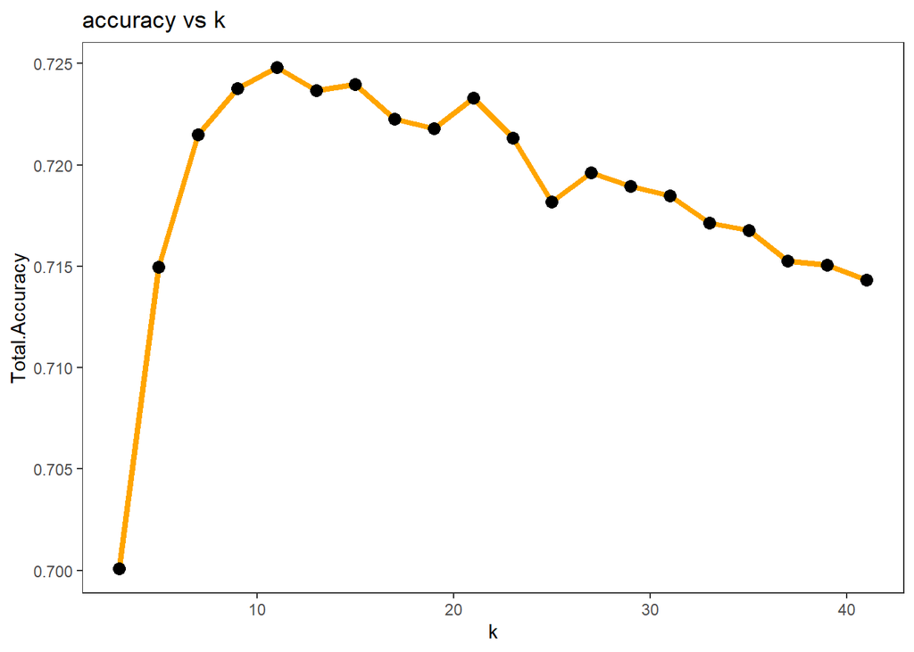

```r
loadPkg("ggplot2")
ggplot(ResultDf2,
       aes(x = k, y = Total.Accuracy)) +
  geom_line(color = "orange", size = 1.5) +
  geom_point(size = 3) +
  labs(title = "accuracy vs k")+
  theme_bw() + theme(panel.grid=element_blank())
```

From this plot we can see that from 3 to 11, the accuracy increases when K increases. When K is between 11 and 21, The accuracy rate is declining fluctuatingly, But when K is larger than 21, the accuracy begins to decrease.  
So, the appropriate K range for KNN model is from 9 to 15, because in this range the KNN models have a great accuracy values.

## Conclusion

### Were we successful in our modelling?

Overall, we were able to create models that successfully predict the target variables.

In the predicting price, it is clear that the numerical data can only go so far, largely due to the multicollinearity. Carat is easily the best single predictor model, so if customers are looking for a computationally easy model or a quick trick to figure our the price of a diamond, they should look at the carat. Beyond that, the categorical variables were definitely helpful in increasing the accuracy of the model, but only to an extent. The C+C+C+C model was the best overall, though it was not that much better than the single carat model. It was mainly better at predicting higher priced diamonds. PCR confirmed these suspicions, by showing the the strength of the model barely increases after one variable.

### Future research

In the future, we would like to obtain a dataset with more information about diamonds. We believe there are still more diamond characteristics that can be used as predictors, so more variables would always be helpful, especially for random forest modelling. We also would want to use a dataset where there are not as many multicollinear variables among the diamonds, that way linear modelling and PCR could be more effective. A dataset with more observations could also be of use, and we could then see if the optimal K value changes for KNN.

On top of dataset changes, we would be interested in looking into other modelling techniques not covered in this report, and see how well they are able to perform in predicting. Lastly, we would like to look into other types of gems, and see if our models are consistent across different types of gems or not.

## References

Agrawal, S. (2017, May 24). Diamonds. Kaggle.com. (https://www.kaggle.com/shivam2503/diamonds)